# Module 103

#### Hemi-module gene counts:

307 probesets in hemi-module A.  
139 probesets in hemi-module B.  
Note: While the mapping of probesets to genes is usually one-to-one, some genes are targeted by multiple probesets, some probesets target multiple genes, and some probesets do not target any genes (i.e., the region of the genome they match is no longer considered genic).

#### Contrast SVE:

Signed variance explained (SVE) provides an indication of how similar a set of fold changes are to a gene module’s weight vector. An SVE value of 0.3, for example, indicates that 30% of the variance explained by the entire module set is accounted for by the module in question. Shown here are the SVE values for this module across a compendium of fold changes (contrasts). Extreme SVE values (e.g., > 0.05) indicate that those contrasts specifically induce (orange dots) or specifically repress (blue dots) this module. Examining the experimental conditions being compared in such contrasts (see tables below the figure) may provide insight into the gene module’s function.

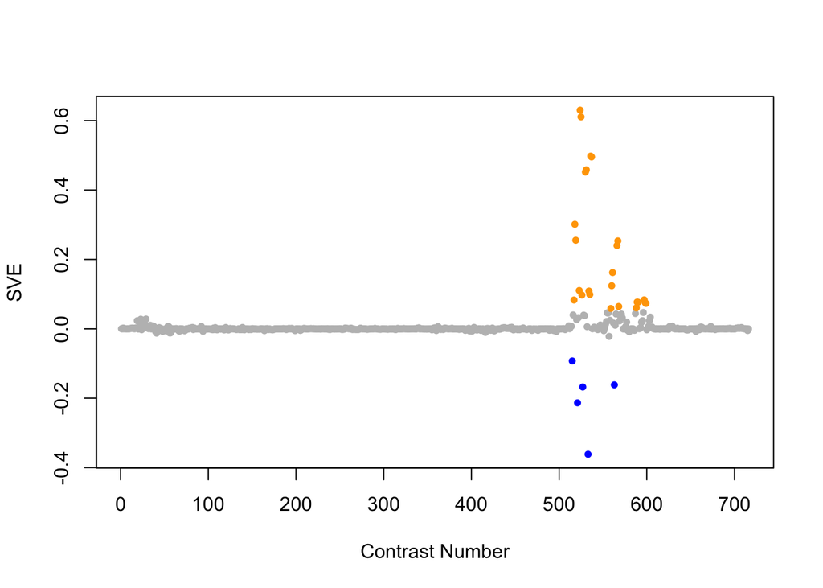

Positive SVE Contrasts:

|  | Contrast.Num | SVE | GEO.GSE | Cond.1 | Cond.2 | Mutation |
| --- | --- | --- | --- | --- | --- | --- |
| GSE2180.s3t8.vs.s2t8 | 524 | 0.63 | GSE2180 | p122-2 | ms122-1 |  |
| GSE2180.s4t8.vs.s2t8 | 525 | 0.61 | GSE2180 | pp122-1 | ms122-1 |  |
| GSE2180.s3t10.vs.s2t10 | 536 | 0.50 | GSE2180 | p186-2 | ms186-5 |  |
| GSE2180.s4t10.vs.s2t10 | 537 | 0.50 | GSE2180 | pp186-1 | ms186-5 |  |
| GSE2180.s4t9.vs.s2t9 | 531 | 0.46 | GSE2180 | pp143-1 | ms143-2 |  |
| GSE2180.s3t9.vs.s2t9 | 530 | 0.45 | GSE2180 | p143-2 | ms143-2 |  |
| GSE2180.s3t7.vs.s2t7 | 518 | 0.30 | GSE2180 | p101-2 | ms101-2 |  |
| GSE2180.s4t7.vs.s2t7 | 519 | 0.26 | GSE2180 | pp101-1 | ms101-2 |  |
| GSE2180.s4t6.vs.s2t6 | 567 | 0.25 | GSE2180 | pp83-1 | ms83-5 |  |
| GSE2180.s3t6.vs.s2t6 | 566 | 0.24 | GSE2180 | p83-2 | ms83-5 |  |
| GSE2180.s4t5.vs.s2t5 | 561 | 0.16 | GSE2180 | pp66-1 | ms66-3 |  |
| GSE2180.s3t5.vs.s2t5 | 560 | 0.12 | GSE2180 | p66-1 | ms66-3 |  |
| GSE2180.s4t8.vs.s1t8 | 523 | 0.11 | GSE2180 | pp122-1 | 122-1 | pie-1(zu154);pal-1(RNAi) |
| GSE2180.s3t10.vs.s1t10 | 534 | 0.11 | GSE2180 | p186-2 | 186-1 | pie-1(zu154) |
| GSE2180.s4t10.vs.s1t10 | 535 | 0.10 | GSE2180 | pp186-1 | 186-1 | pie-1(zu154);pal-1(RNAi) |
| GSE2180.s4t8.vs.s3t8 | 526 | 0.10 | GSE2180 | pp122-1 | p122-2 | pal-1(RNAi) |
| GSE2180.s4t8.vs.s4t1 | 597 | 0.08 | GSE2180 | pp122-1 | pp0-1 |  |
| GSE2180.s4t7.vs.s1t7 | 517 | 0.08 | GSE2180 | pp101-1 | 101G | pie-1(zu154);pal-1(RNAi) |
| GSE2180.s3t9.vs.s3t1 | 589 | 0.08 | GSE2180 | p143-2 | p0-3 |  |
| GSE2180.s3t10.vs.s3t1 | 590 | 0.08 | GSE2180 | p186-2 | p0-3 |  |
| GSE2180.s4t9.vs.s4t1 | 598 | 0.08 | GSE2180 | pp143-1 | pp0-1 |  |
| GSE2180.s4t10.vs.s4t1 | 599 | 0.07 | GSE2180 | pp186-1 | pp0-1 |  |
| GSE2180.s4t6.vs.s3t6 | 568 | 0.06 | GSE2180 | pp83-1 | p83-2 | pal-1(RNAi) |
| GSE2180.s3t8.vs.s3t1 | 588 | 0.06 | GSE2180 | p122-2 | p0-3 |  |
| GSE2180.s4t5.vs.s1t5 | 559 | 0.06 | GSE2180 | pp66-1 | 66-4 | pie-1(zu154);pal-1(RNAi) |

Negative SVE Contrasts:

|  | Contrast.Num | SVE | GEO.GSE | Cond.1 | Cond.2 | Mutation |
| --- | --- | --- | --- | --- | --- | --- |
| GSE2180.s2t10.vs.s1t10 | 533 | -0.36 | GSE2180 | ms186-5 | 186-1 | mex-3(zu155);skn-1(RNAi) |
| GSE2180.s2t8.vs.s1t8 | 521 | -0.21 | GSE2180 | ms122-1 | 122-1 | mex-3(zu155);skn-1(RNAi) |
| GSE2180.s2t9.vs.s1t9 | 527 | -0.17 | GSE2180 | ms143-2 | 143L | mex-3(zu155);skn-1(RNAi) |
| GSE2180.s2t6.vs.s1t6 | 563 | -0.16 | GSE2180 | ms83-5 | 83-1 | mex-3(zu155);skn-1(RNAi) |
| GSE2180.s2t7.vs.s1t7 | 515 | -0.09 | GSE2180 | ms101-2 | 101G | mex-3(zu155);skn-1(RNAi) |

$~$

#### Contrast SVE, Up-Regulated Genes Only:

Calculating SVE for up-regulated and down-regulated genes separately may be more informative in many cases than projecting the up- and down- gene sets together. This is due to the fact that the weight distribution of many modules is highly skewed, indicating that only one of the hemi-modules may be biologically meaningful (i.e., a set of genes are strongly correlated by only a few genes (or none) are strongly anti-correlated to that set.)

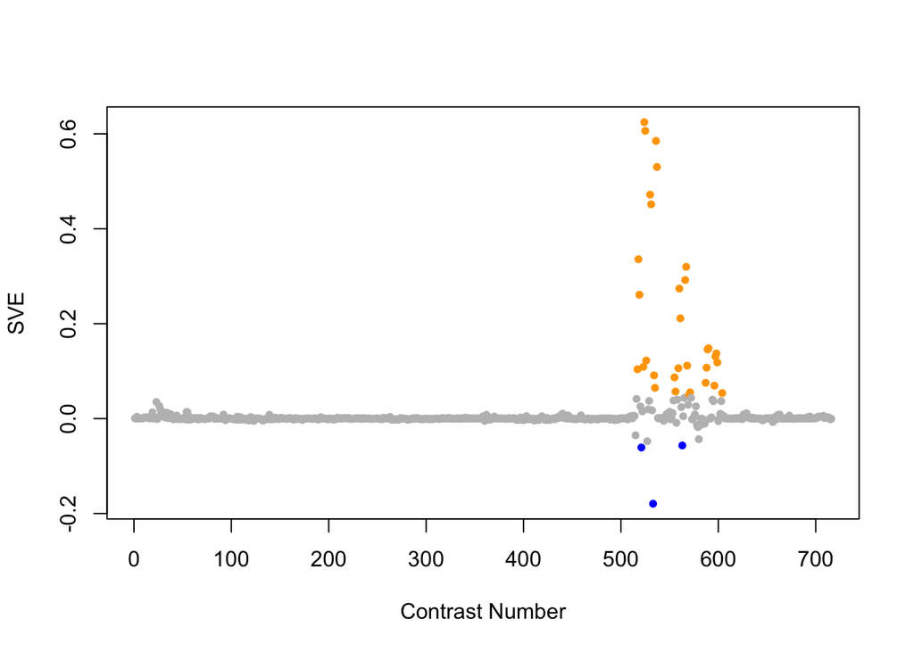

Positive SVE Contrasts:

|  | Contrast.Num | SVE | GEO.GSE | Cond.1 | Cond.2 | Mutation |
| --- | --- | --- | --- | --- | --- | --- |
| GSE2180.s3t8.vs.s2t8 | 524 | 0.62 | GSE2180 | p122-2 | ms122-1 |  |
| GSE2180.s4t8.vs.s2t8 | 525 | 0.61 | GSE2180 | pp122-1 | ms122-1 |  |
| GSE2180.s3t10.vs.s2t10 | 536 | 0.59 | GSE2180 | p186-2 | ms186-5 |  |
| GSE2180.s4t10.vs.s2t10 | 537 | 0.53 | GSE2180 | pp186-1 | ms186-5 |  |
| GSE2180.s3t9.vs.s2t9 | 530 | 0.47 | GSE2180 | p143-2 | ms143-2 |  |
| GSE2180.s4t9.vs.s2t9 | 531 | 0.45 | GSE2180 | pp143-1 | ms143-2 |  |
| GSE2180.s3t7.vs.s2t7 | 518 | 0.34 | GSE2180 | p101-2 | ms101-2 |  |
| GSE2180.s4t6.vs.s2t6 | 567 | 0.32 | GSE2180 | pp83-1 | ms83-5 |  |
| GSE2180.s3t6.vs.s2t6 | 566 | 0.29 | GSE2180 | p83-2 | ms83-5 |  |
| GSE2180.s3t5.vs.s2t5 | 560 | 0.27 | GSE2180 | p66-1 | ms66-3 |  |
| GSE2180.s4t7.vs.s2t7 | 519 | 0.26 | GSE2180 | pp101-1 | ms101-2 |  |
| GSE2180.s4t5.vs.s2t5 | 561 | 0.21 | GSE2180 | pp66-1 | ms66-3 |  |
| GSE2180.s3t10.vs.s3t1 | 590 | 0.15 | GSE2180 | p186-2 | p0-3 |  |
| GSE2180.s3t9.vs.s3t1 | 589 | 0.15 | GSE2180 | p143-2 | p0-3 |  |
| GSE2180.s4t9.vs.s4t1 | 598 | 0.14 | GSE2180 | pp143-1 | pp0-1 |  |
| GSE2180.s4t8.vs.s4t1 | 597 | 0.13 | GSE2180 | pp122-1 | pp0-1 |  |
| GSE2180.s4t8.vs.s3t8 | 526 | 0.12 | GSE2180 | pp122-1 | p122-2 | pal-1(RNAi) |
| GSE2180.s4t10.vs.s4t1 | 599 | 0.12 | GSE2180 | pp186-1 | pp0-1 |  |
| GSE2180.s4t6.vs.s3t6 | 568 | 0.11 | GSE2180 | pp83-1 | p83-2 | pal-1(RNAi) |
| GSE2180.s4t8.vs.s1t8 | 523 | 0.11 | GSE2180 | pp122-1 | 122-1 | pie-1(zu154);pal-1(RNAi) |
| GSE2180.s3t8.vs.s3t1 | 588 | 0.11 | GSE2180 | p122-2 | p0-3 |  |
| GSE2180.s4t5.vs.s1t5 | 559 | 0.11 | GSE2180 | pp66-1 | 66-4 | pie-1(zu154);pal-1(RNAi) |
| GSE2180.s4t7.vs.s1t7 | 517 | 0.10 | GSE2180 | pp101-1 | 101G | pie-1(zu154);pal-1(RNAi) |
| GSE2180.s3t10.vs.s1t10 | 534 | 0.09 | GSE2180 | p186-2 | 186-1 | pie-1(zu154) |
| GSE2180.s4t4.vs.s2t4 | 555 | 0.09 | GSE2180 | pp53-1 | ms53-4 |  |
| GSE2180.s3t7.vs.s3t1 | 587 | 0.08 | GSE2180 | p101-2 | p0-3 |  |
| GSE2180.s4t7.vs.s4t1 | 596 | 0.07 | GSE2180 | pp101-1 | pp0-1 |  |
| GSE2180.s4t10.vs.s1t10 | 535 | 0.06 | GSE2180 | pp186-1 | 186-1 | pie-1(zu154);pal-1(RNAi) |
| GSE2180.s4t4.vs.s3t4 | 556 | 0.06 | GSE2180 | pp53-1 | p53-2 |  |
| GSE2180.s1t9.vs.s1t1 | 571 | 0.06 | GSE2180 | 143L | 00B |  |
| GSE2180.s4t6.vs.s4t1 | 604 | 0.05 | GSE2180 | pp83-1 | pp0-1 |  |
| GSE2180.s1t8.vs.s1t1 | 570 | 0.05 | GSE2180 | 122-1 | 00B |  |

Negative SVE Contrasts:

|  | Contrast.Num | SVE | GEO.GSE | Cond.1 | Cond.2 | Mutation |
| --- | --- | --- | --- | --- | --- | --- |
| GSE2180.s2t10.vs.s1t10 | 533 | -0.18 | GSE2180 | ms186-5 | 186-1 | mex-3(zu155);skn-1(RNAi) |
| GSE2180.s2t8.vs.s1t8 | 521 | -0.06 | GSE2180 | ms122-1 | 122-1 | mex-3(zu155);skn-1(RNAi) |
| GSE2180.s2t6.vs.s1t6 | 563 | -0.06 | GSE2180 | ms83-5 | 83-1 | mex-3(zu155);skn-1(RNAi) |
| GSE2180.s2t9.vs.s1t9 | 527 | -0.05 | GSE2180 | ms143-2 | 143L | mex-3(zu155);skn-1(RNAi) |
| GSE2180.s2t9.vs.s2t1 | 580 | -0.04 | GSE2180 | ms143-2 | ms0-1 |  |

$~$

#### Contrast SVE, Down-Regulated Genes Only:

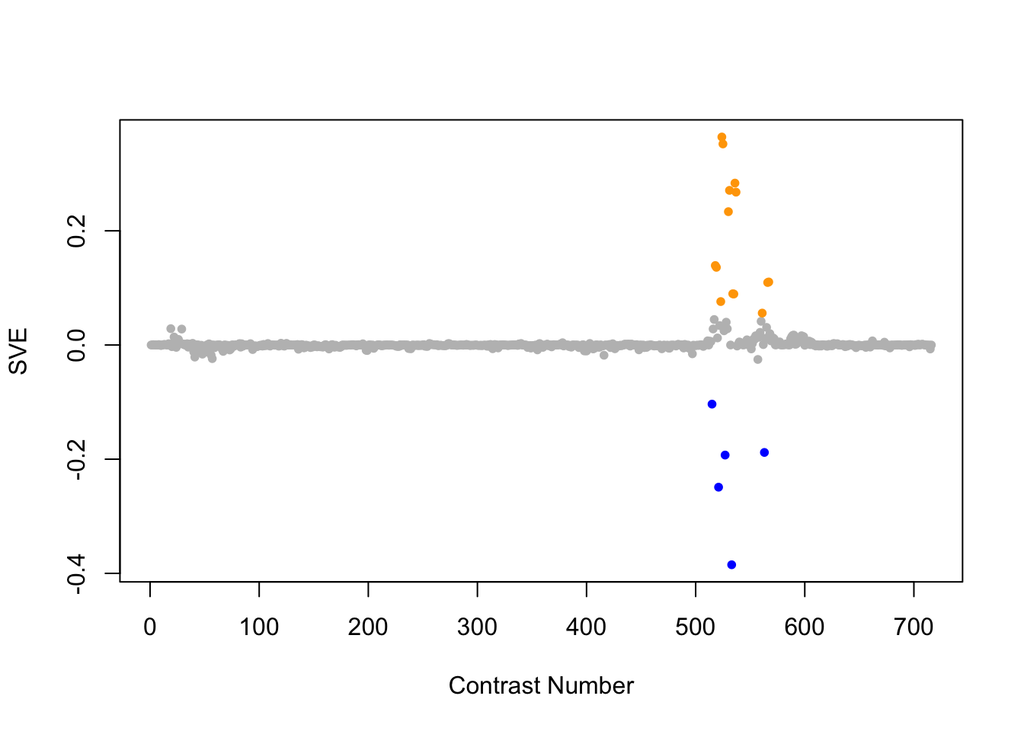

Positive SVE Contrasts:

|  | Contrast.Num | SVE | GEO.GSE | Cond.1 | Cond.2 | Mutation |
| --- | --- | --- | --- | --- | --- | --- |
| GSE2180.s3t8.vs.s2t8 | 524 | 0.36 | GSE2180 | p122-2 | ms122-1 |  |
| GSE2180.s4t8.vs.s2t8 | 525 | 0.35 | GSE2180 | pp122-1 | ms122-1 |  |
| GSE2180.s3t10.vs.s2t10 | 536 | 0.28 | GSE2180 | p186-2 | ms186-5 |  |
| GSE2180.s4t9.vs.s2t9 | 531 | 0.27 | GSE2180 | pp143-1 | ms143-2 |  |
| GSE2180.s4t10.vs.s2t10 | 537 | 0.27 | GSE2180 | pp186-1 | ms186-5 |  |
| GSE2180.s3t9.vs.s2t9 | 530 | 0.23 | GSE2180 | p143-2 | ms143-2 |  |
| GSE2180.s3t7.vs.s2t7 | 518 | 0.14 | GSE2180 | p101-2 | ms101-2 |  |
| GSE2180.s4t7.vs.s2t7 | 519 | 0.14 | GSE2180 | pp101-1 | ms101-2 |  |
| GSE2180.s4t6.vs.s2t6 | 567 | 0.11 | GSE2180 | pp83-1 | ms83-5 |  |
| GSE2180.s3t6.vs.s2t6 | 566 | 0.11 | GSE2180 | p83-2 | ms83-5 |  |
| GSE2180.s3t10.vs.s1t10 | 534 | 0.09 | GSE2180 | p186-2 | 186-1 | pie-1(zu154) |
| GSE2180.s4t10.vs.s1t10 | 535 | 0.09 | GSE2180 | pp186-1 | 186-1 | pie-1(zu154);pal-1(RNAi) |
| GSE2180.s4t8.vs.s1t8 | 523 | 0.08 | GSE2180 | pp122-1 | 122-1 | pie-1(zu154);pal-1(RNAi) |
| GSE2180.s4t5.vs.s2t5 | 561 | 0.06 | GSE2180 | pp66-1 | ms66-3 |  |

Negative SVE Contrasts:

|  | Contrast.Num | SVE | GEO.GSE | Cond.1 | Cond.2 | Mutation |
| --- | --- | --- | --- | --- | --- | --- |
| GSE2180.s2t10.vs.s1t10 | 533 | -0.38 | GSE2180 | ms186-5 | 186-1 | mex-3(zu155);skn-1(RNAi) |
| GSE2180.s2t8.vs.s1t8 | 521 | -0.25 | GSE2180 | ms122-1 | 122-1 | mex-3(zu155);skn-1(RNAi) |
| GSE2180.s2t9.vs.s1t9 | 527 | -0.19 | GSE2180 | ms143-2 | 143L | mex-3(zu155);skn-1(RNAi) |
| GSE2180.s2t6.vs.s1t6 | 563 | -0.19 | GSE2180 | ms83-5 | 83-1 | mex-3(zu155);skn-1(RNAi) |
| GSE2180.s2t7.vs.s1t7 | 515 | -0.10 | GSE2180 | ms101-2 | 101G | mex-3(zu155);skn-1(RNAi) |

$~$

$~$

#### GO Term Enrichment:

This analysis tests each hemi-module for enrichment of specific GO terms. Only gene-level annotations (e.g., as would be found on the gene’s page in Wormbase) are tested - the hierarchical structure of the GO ontology is not taken into account.

*Note: At least the top two most enriched terms from each GO domain (BP/MF/CC) are shown, even when not statistically significant.*

##### Enriched GO terms: Hemi-module A

| ID | GO.Term | GO Domain | Raw p-value | Adj p-value |
| --- | --- | --- | --- | --- |
| [GO_0055114](http://amigo.geneontology.org/amigo/term/GO:0055114) | oxidation-reduction process | BP | 2.85e-13 | 1.04e-09 |
| [GO_0016558](http://amigo.geneontology.org/amigo/term/GO:0016558) | protein import into peroxisome matrix | BP | 2.21e-06 | 4.02e-03 |
| [GO_0008152](http://amigo.geneontology.org/amigo/term/GO:0008152) | metabolic process | BP | 5.03e-06 | 4.19e-03 |
| [GO_0009116](http://amigo.geneontology.org/amigo/term/GO:0009116) | nucleoside metabolic process | BP | 5.07e-06 | 4.19e-03 |
| [GO_0006635](http://amigo.geneontology.org/amigo/term/GO:0006635) | fatty acid beta-oxidation | BP | 5.75e-06 | 4.19e-03 |
| [GO_0005975](http://amigo.geneontology.org/amigo/term/GO:0005975) | carbohydrate metabolic process | BP | 2.82e-05 | 1.23e-02 |
| [GO_0006166](http://amigo.geneontology.org/amigo/term/GO:0006166) | purine ribonucleoside salvage | BP | 3.05e-05 | 1.23e-02 |
| [GO_0055129](http://amigo.geneontology.org/amigo/term/GO:0055129) | L-proline biosynthetic process | BP | 3.05e-05 | 1.23e-02 |
| [GO_1904070](http://amigo.geneontology.org/amigo/term/GO:1904070) | ascaroside biosynthetic process | BP | 3.05e-05 | 1.23e-02 |
| [GO_0006631](http://amigo.geneontology.org/amigo/term/GO:0006631) | fatty acid metabolic process | BP | 6.14e-05 | 2.24e-02 |
| [GO_0006572](http://amigo.geneontology.org/amigo/term/GO:0006572) | tyrosine catabolic process | BP | 7.52e-05 | 2.28e-02 |
| [GO_0033540](http://amigo.geneontology.org/amigo/term/GO:0033540) | fatty acid beta-oxidation using acyl-CoA oxidase | BP | 7.52e-05 | 2.28e-02 |
| [GO_0006625](http://amigo.geneontology.org/amigo/term/GO:0006625) | protein targeting to peroxisome | BP | 1.48e-04 | 3.85e-02 |
| [GO_0007031](http://amigo.geneontology.org/amigo/term/GO:0007031) | peroxisome organization | BP | 1.48e-04 | 3.85e-02 |
| [GO_1904937](http://amigo.geneontology.org/amigo/term/GO:1904937) | sensory neuron migration | BP | 2.55e-04 | 6.20e-02 |
| [GO_0006357](http://amigo.geneontology.org/amigo/term/GO:0006357) | regulation of transcription by RNA polymerase II | BP | 2.76e-04 | 6.28e-02 |
| [GO_0006520](http://amigo.geneontology.org/amigo/term/GO:0006520) | cellular amino acid metabolic process | BP | 3.73e-04 | 6.82e-02 |
| [GO_0000038](http://amigo.geneontology.org/amigo/term/GO:0000038) | very long-chain fatty acid metabolic process | BP | 3.93e-04 | 6.82e-02 |
| [GO_0006044](http://amigo.geneontology.org/amigo/term/GO:0006044) | N-acetylglucosamine metabolic process | BP | 3.93e-04 | 6.82e-02 |
| [GO_0006046](http://amigo.geneontology.org/amigo/term/GO:0006046) | N-acetylglucosamine catabolic process | BP | 3.93e-04 | 6.82e-02 |
| [GO_0006168](http://amigo.geneontology.org/amigo/term/GO:0006168) | adenine salvage | BP | 3.93e-04 | 6.82e-02 |
| [GO_0007186](http://amigo.geneontology.org/amigo/term/GO:0007186) | G protein-coupled receptor signaling pathway | BP | 4.51e-04 | 7.47e-02 |
| [GO_0003824](http://amigo.geneontology.org/amigo/term/GO:0003824) | catalytic activity | MF | 1.14e-10 | 2.32e-07 |
| [GO_0016491](http://amigo.geneontology.org/amigo/term/GO:0016491) | oxidoreductase activity | MF | 1.26e-09 | 1.29e-06 |
| [GO_0008194](http://amigo.geneontology.org/amigo/term/GO:0008194) | UDP-glycosyltransferase activity | MF | 5.25e-08 | 3.58e-05 |
| [GO_0016758](http://amigo.geneontology.org/amigo/term/GO:0016758) | transferase activity, transferring hexosyl groups | MF | 1.57e-07 | 8.01e-05 |
| [GO_0016787](http://amigo.geneontology.org/amigo/term/GO:0016787) | hydrolase activity | MF | 4.15e-07 | 1.70e-04 |
| [GO_0016798](http://amigo.geneontology.org/amigo/term/GO:0016798) | hydrolase activity, acting on glycosyl bonds | MF | 2.46e-06 | 8.39e-04 |
| [GO_0004553](http://amigo.geneontology.org/amigo/term/GO:0004553) | hydrolase activity, hydrolyzing O-glycosyl compounds | MF | 2.06e-05 | 6.00e-03 |
| [GO_0004046](http://amigo.geneontology.org/amigo/term/GO:0004046) | aminoacylase activity | MF | 3.05e-05 | 7.79e-03 |
| [GO_0000981](http://amigo.geneontology.org/amigo/term/GO:0000981) | DNA-binding transcription factor activity, RNA polymerase II-specific | MF | 7.06e-05 | 1.54e-02 |
| [GO_0003997](http://amigo.geneontology.org/amigo/term/GO:0003997) | acyl-CoA oxidase activity | MF | 7.52e-05 | 1.54e-02 |
| [GO_0016887](http://amigo.geneontology.org/amigo/term/GO:0016887) | ATPase activity | MF | 1.46e-04 | 2.71e-02 |
| [GO_0015020](http://amigo.geneontology.org/amigo/term/GO:0015020) | glucuronosyltransferase activity | MF | 2.01e-04 | 3.42e-02 |
| [GO_0016620](http://amigo.geneontology.org/amigo/term/GO:0016620) | oxidoreductase activity, acting on the aldehyde or oxo group of donors, NAD or NADP as acceptor | MF | 2.29e-04 | 3.60e-02 |
| [GO_0005504](http://amigo.geneontology.org/amigo/term/GO:0005504) | fatty acid binding | MF | 2.55e-04 | 3.73e-02 |
| [GO_0030170](http://amigo.geneontology.org/amigo/term/GO:0030170) | pyridoxal phosphate binding | MF | 3.52e-04 | 4.80e-02 |
| [GO_0004096](http://amigo.geneontology.org/amigo/term/GO:0004096) | catalase activity | MF | 3.93e-04 | 5.02e-02 |
| [GO_0042626](http://amigo.geneontology.org/amigo/term/GO:0042626) | ATPase activity, coupled to transmembrane movement of substances | MF | 4.41e-04 | 5.30e-02 |
| [GO_0046872](http://amigo.geneontology.org/amigo/term/GO:0046872) | metal ion binding | MF | 5.60e-04 | 6.36e-02 |
| [GO_0017147](http://amigo.geneontology.org/amigo/term/GO:0017147) | Wnt-protein binding | MF | 5.95e-04 | 6.40e-02 |
| [GO_0042802](http://amigo.geneontology.org/amigo/term/GO:0042802) | identical protein binding | MF | 7.62e-04 | 7.78e-02 |
| [GO_0016757](http://amigo.geneontology.org/amigo/term/GO:0016757) | transferase activity, transferring glycosyl groups | MF | 9.78e-04 | 9.52e-02 |
| [GO_0005777](http://amigo.geneontology.org/amigo/term/GO:0005777) | peroxisome | CC | 8.93e-18 | 8.29e-15 |
| [GO_0043231](http://amigo.geneontology.org/amigo/term/GO:0043231) | intracellular membrane-bounded organelle | CC | 8.90e-06 | 4.13e-03 |
| [GO_0044841](http://amigo.geneontology.org/amigo/term/GO:0044841) | gut granule membrane | CC | 3.05e-05 | 9.44e-03 |
| [GO_0005778](http://amigo.geneontology.org/amigo/term/GO:0005778) | peroxisomal membrane | CC | 9.43e-05 | 2.19e-02 |
| [GO_0005811](http://amigo.geneontology.org/amigo/term/GO:0005811) | lipid droplet | CC | 3.73e-04 | 6.92e-02 |

##### Enriched GO terms: Hemi-module B

| ID | GO.Term | GO Domain | Raw p-value | Adj p-value |
| --- | --- | --- | --- | --- |
| [GO_0055114](http://amigo.geneontology.org/amigo/term/GO:0055114) | oxidation-reduction process | BP | 3.26e-06 | 1.19e-02 |
| [GO_0010172](http://amigo.geneontology.org/amigo/term/GO:0010172) | embryonic body morphogenesis | BP | 1.15e-05 | 2.09e-02 |
| [GO_0016491](http://amigo.geneontology.org/amigo/term/GO:0016491) | oxidoreductase activity | MF | 3.01e-07 | 6.14e-04 |
| [GO_0000977](http://amigo.geneontology.org/amigo/term/GO:0000977) | RNA polymerase II regulatory region sequence-specific DNA binding | MF | 8.84e-06 | 9.03e-03 |
| [GO_0016616](http://amigo.geneontology.org/amigo/term/GO:0016616) | oxidoreductase activity, acting on the CH-OH group of donors, NAD or NADP as acceptor | MF | 2.70e-05 | 1.84e-02 |
| [GO_0003700](http://amigo.geneontology.org/amigo/term/GO:0003700) | DNA-binding transcription factor activity | MF | 5.55e-05 | 2.68e-02 |
| [GO_0016639](http://amigo.geneontology.org/amigo/term/GO:0016639) | oxidoreductase activity, acting on the CH-NH2 group of donors, NAD or NADP as acceptor | MF | 6.57e-05 | 2.68e-02 |
| [GO_0016020](http://amigo.geneontology.org/amigo/term/GO:0016020) | membrane | CC | 2.97e-06 | 1.61e-03 |
| [GO_0016021](http://amigo.geneontology.org/amigo/term/GO:0016021) | integral component of membrane | CC | 3.47e-06 | 1.61e-03 |

$~$

$~$

#### Tissue Enrichment:

This analysis tests each hemi-module for enrichment of genes associated with anatomy terms. Negative enrichment scores indicate fewer hemi-module genes than expected by random chance were associated with the anatomy term in question.

##### Enriched tissues: Hemi-module A

| ID | Anatomy.Term | Definition | Raw p-value | Adj p-value |
| --- | --- | --- | --- | --- |
| [WBbt_0005772](https://wormbase.org/species/all/anatomy_term/WBbt:0005772) | intestine | A chain of very large cuboidal cells forming a wide central lumen in which food arrives from the posterior pharynx, is digested, and from which waste products proceed to the rectum. Intestinal rings f… | 6.59e-11 | 1.60e-07 |
| [WBbt_0006104](https://wormbase.org/species/all/anatomy_term/WBbt:0006104) | Eala | embryonic cell | 4.78e-07 | 3.22e-04 |
| [WBbt_0006547](https://wormbase.org/species/all/anatomy_term/WBbt:0006547) | Epr | embryonic cell | 4.78e-07 | 3.22e-04 |
| [WBbt_0006161](https://wormbase.org/species/all/anatomy_term/WBbt:0006161) | Eara | embryonic cell | 7.47e-07 | 3.22e-04 |
| [WBbt_0006546](https://wormbase.org/species/all/anatomy_term/WBbt:0006546) | Ealp | embryonic cell | 9.25e-07 | 3.22e-04 |
| [WBbt_0006646](https://wormbase.org/species/all/anatomy_term/WBbt:0006646) | Earp | embryonic cell | 9.25e-07 | 3.22e-04 |
| [WBbt_0006661](https://wormbase.org/species/all/anatomy_term/WBbt:0006661) | Epla | embryonic cell | 9.25e-07 | 3.22e-04 |
| [WBbt_0006496](https://wormbase.org/species/all/anatomy_term/WBbt:0006496) | Eplp | embryonic cell | 2.05e-06 | 6.24e-04 |
| [WBbt_0006370](https://wormbase.org/species/all/anatomy_term/WBbt:0006370) | Ear | embryonic cell | 2.37e-06 | 6.40e-04 |
| [WBbt_0006441](https://wormbase.org/species/all/anatomy_term/WBbt:0006441) | Eal | embryonic cell | 3.67e-06 | 8.92e-04 |
| [WBbt_0006000](https://wormbase.org/species/all/anatomy_term/WBbt:0006000) | Epl | embryonic cell | 4.51e-06 | 9.98e-04 |
| [WBbt_0006321](https://wormbase.org/species/all/anatomy_term/WBbt:0006321) | Epra | embryonic cell | 1.94e-05 | 3.94e-03 |
| [WBbt_0006507](https://wormbase.org/species/all/anatomy_term/WBbt:0006507) | Eprp | embryonic cell | 2.67e-05 | 5.00e-03 |
| [WBbt_0006733](https://wormbase.org/species/all/anatomy_term/WBbt:0006733) | Ea | embryonic cell | 2.15e-04 | 3.74e-02 |
| [WBbt_0006346](https://wormbase.org/species/all/anatomy_term/WBbt:0006346) | ABprppap | embryonic cell | 2.95e-04 | 4.79e-02 |
| [WBbt_0006427](https://wormbase.org/species/all/anatomy_term/WBbt:0006427) | ABalaaaa | embryonic cell | 3.43e-04 | 4.91e-02 |
| [WBbt_0006612](https://wormbase.org/species/all/anatomy_term/WBbt:0006612) | Ep | embryonic cell | 3.43e-04 | 4.91e-02 |
| [WBbt_0005978](https://wormbase.org/species/all/anatomy_term/WBbt:0005978) | ABaraappa | embryonic cell | 4.24e-04 | 5.73e-02 |
| [WBbt_0005852](https://wormbase.org/species/all/anatomy_term/WBbt:0005852) | ABprpapp | embryonic cell | 5.10e-04 | 6.53e-02 |
| [WBbt_0006536](https://wormbase.org/species/all/anatomy_term/WBbt:0006536) | MSaapa | embryonic cell | 6.08e-04 | 7.12e-02 |
| [WBbt_0006081](https://wormbase.org/species/all/anatomy_term/WBbt:0006081) | Dappa | embryonic cell | 6.44e-04 | 7.12e-02 |
| [WBbt_0006482](https://wormbase.org/species/all/anatomy_term/WBbt:0006482) | Dpppa | embryonic cell | 6.44e-04 | 7.12e-02 |

##### Enriched tissues: Hemi-module B

| ID | Anatomy.Term | Definition | Raw p-value | Adj p-value |
| --- | --- | --- | --- | --- |
| [WBbt_0006016](https://wormbase.org/species/all/anatomy_term/WBbt:0006016) | MSppppp | embryonic cell | 1.30e-07 | 1.58e-04 |
| [WBbt_0006218](https://wormbase.org/species/all/anatomy_term/WBbt:0006218) | MSppppa | embryonic cell | 1.30e-07 | 1.58e-04 |
| [WBbt_0006267](https://wormbase.org/species/all/anatomy_term/WBbt:0006267) | Caaap | embryonic cell | 7.05e-07 | 3.64e-04 |
| [WBbt_0006722](https://wormbase.org/species/all/anatomy_term/WBbt:0006722) | Caapp | embryonic cell | 8.45e-07 | 3.64e-04 |
| [WBbt_0006107](https://wormbase.org/species/all/anatomy_term/WBbt:0006107) | MSapppp | embryonic cell | 9.59e-07 | 3.64e-04 |
| [WBbt_0005962](https://wormbase.org/species/all/anatomy_term/WBbt:0005962) | Cpapa | embryonic cell | 9.74e-07 | 3.64e-04 |
| [WBbt_0005897](https://wormbase.org/species/all/anatomy_term/WBbt:0005897) | Cpapp | embryonic cell | 1.14e-06 | 3.64e-04 |
| [WBbt_0006042](https://wormbase.org/species/all/anatomy_term/WBbt:0006042) | MSapppa | embryonic cell | 1.35e-06 | 3.64e-04 |
| [WBbt_0006492](https://wormbase.org/species/all/anatomy_term/WBbt:0006492) | MSapapp | embryonic cell | 1.35e-06 | 3.64e-04 |
| [WBbt_0005899](https://wormbase.org/species/all/anatomy_term/WBbt:0005899) | Caaaa | embryonic cell | 4.78e-06 | 1.16e-03 |
| [WBbt_0006268](https://wormbase.org/species/all/anatomy_term/WBbt:0006268) | Cppp | embryonic cell | 6.58e-06 | 1.24e-03 |
| [WBbt_0006594](https://wormbase.org/species/all/anatomy_term/WBbt:0006594) | Cpaap | embryonic cell | 6.58e-06 | 1.24e-03 |
| [WBbt_0006073](https://wormbase.org/species/all/anatomy_term/WBbt:0006073) | MSppapp | embryonic cell | 6.91e-06 | 1.24e-03 |
| [WBbt_0006098](https://wormbase.org/species/all/anatomy_term/WBbt:0006098) | Capp | embryonic cell | 7.67e-06 | 1.24e-03 |
| [WBbt_0006212](https://wormbase.org/species/all/anatomy_term/WBbt:0006212) | Cpaaa | embryonic cell | 7.67e-06 | 1.24e-03 |
| [WBbt_0006444](https://wormbase.org/species/all/anatomy_term/WBbt:0006444) | Capa | embryonic cell | 1.03e-05 | 1.56e-03 |
| [WBbt_0006168](https://wormbase.org/species/all/anatomy_term/WBbt:0006168) | Cppa | embryonic cell | 2.27e-05 | 3.25e-03 |
| [WBbt_0006239](https://wormbase.org/species/all/anatomy_term/WBbt:0006239) | MSapapa | embryonic cell | 2.60e-05 | 3.51e-03 |
| [WBbt_0006718](https://wormbase.org/species/all/anatomy_term/WBbt:0006718) | Dp | embryonic cell | 7.11e-05 | 9.10e-03 |
| [WBbt_0006123](https://wormbase.org/species/all/anatomy_term/WBbt:0006123) | Caapa | embryonic cell | 7.84e-05 | 9.54e-03 |
| [WBbt_0006714](https://wormbase.org/species/all/anatomy_term/WBbt:0006714) | MSaappp | embryonic cell | 1.30e-04 | 1.51e-02 |
| [WBbt_0006516](https://wormbase.org/species/all/anatomy_term/WBbt:0006516) | Cpaa | embryonic cell | 1.56e-04 | 1.73e-02 |
| [WBbt_0006059](https://wormbase.org/species/all/anatomy_term/WBbt:0006059) | Cpppp | embryonic cell | 2.19e-04 | 2.32e-02 |
| [WBbt_0005813](https://wormbase.org/species/all/anatomy_term/WBbt:0005813) | body wall musculature | Longitudinal bands of muscle cells surrounding animal body, with one band running in each quadrant of the body, regulated contraction and relaxation of these muscles cause locomotion. | 2.35e-04 | 2.38e-02 |
| [WBbt_0006024](https://wormbase.org/species/all/anatomy_term/WBbt:0006024) | Cpppa | embryonic cell | 2.57e-04 | 2.50e-02 |
| [WBbt_0006200](https://wormbase.org/species/all/anatomy_term/WBbt:0006200) | MSaappa | embryonic cell | 2.99e-04 | 2.80e-02 |
| [WBbt_0006628](https://wormbase.org/species/all/anatomy_term/WBbt:0006628) | Cpap | embryonic cell | 3.45e-04 | 3.11e-02 |
| [WBbt_0006045](https://wormbase.org/species/all/anatomy_term/WBbt:0006045) | Dpa | embryonic cell | 4.54e-04 | 3.94e-02 |
| [WBbt_0006273](https://wormbase.org/species/all/anatomy_term/WBbt:0006273) | ABarpappa | embryonic cell | 5.16e-04 | 4.33e-02 |
| [WBbt_0006656](https://wormbase.org/species/all/anatomy_term/WBbt:0006656) | ABplapppp | embryonic cell | 5.85e-04 | 4.50e-02 |
| [WBbt_0005980](https://wormbase.org/species/all/anatomy_term/WBbt:0005980) | Ca | embryonic cell | 5.92e-04 | 4.50e-02 |
| [WBbt_0006117](https://wormbase.org/species/all/anatomy_term/WBbt:0006117) | Cp | embryonic cell | 5.92e-04 | 4.50e-02 |
| [WBbt_0006290](https://wormbase.org/species/all/anatomy_term/WBbt:0006290) | ABprapapp | embryonic cell | 6.59e-04 | 4.86e-02 |
| [WBbt_0006258](https://wormbase.org/species/all/anatomy_term/WBbt:0006258) | Dppp | embryonic cell | 7.33e-04 | 4.87e-02 |
| [WBbt_0006512](https://wormbase.org/species/all/anatomy_term/WBbt:0006512) | Da | embryonic cell | 7.33e-04 | 4.87e-02 |
| [WBbt_0006240](https://wormbase.org/species/all/anatomy_term/WBbt:0006240) | ABarppapp | embryonic cell | 7.40e-04 | 4.87e-02 |
| [WBbt_0006510](https://wormbase.org/species/all/anatomy_term/WBbt:0006510) | ABprapapa | embryonic cell | 7.40e-04 | 4.87e-02 |
| [WBbt_0006220](https://wormbase.org/species/all/anatomy_term/WBbt:0006220) | ABprappap | embryonic cell | 8.28e-04 | 5.17e-02 |
| [WBbt_0006350](https://wormbase.org/species/all/anatomy_term/WBbt:0006350) | ABprappaa | embryonic cell | 8.28e-04 | 5.17e-02 |
| [WBbt_0005870](https://wormbase.org/species/all/anatomy_term/WBbt:0005870) | Dapp | embryonic cell | 8.95e-04 | 5.44e-02 |
| [WBbt_0005921](https://wormbase.org/species/all/anatomy_term/WBbt:0005921) | Caap | embryonic cell | 9.23e-04 | 5.48e-02 |
| [WBbt_0006106](https://wormbase.org/species/all/anatomy_term/WBbt:0006106) | Dppa | embryonic cell | 1.08e-03 | 6.24e-02 |
| [WBbt_0006612](https://wormbase.org/species/all/anatomy_term/WBbt:0006612) | Ep | embryonic cell | 1.14e-03 | 6.42e-02 |
| [WBbt_0003675](https://wormbase.org/species/all/anatomy_term/WBbt:0003675) | muscle cell | contractile cell that makes up muscle tissue. | 1.23e-03 | 6.77e-02 |
| [WBbt_0006004](https://wormbase.org/species/all/anatomy_term/WBbt:0006004) | Dapa | embryonic cell | 1.28e-03 | 6.77e-02 |
| [WBbt_0006734](https://wormbase.org/species/all/anatomy_term/WBbt:0006734) | MSpppaa | embryonic cell | 1.28e-03 | 6.77e-02 |
| [WBbt_0005848](https://wormbase.org/species/all/anatomy_term/WBbt:0005848) | MSppapap | Embryonic cell of pedigree MSppapap. | 1.46e-03 | 7.27e-02 |
| [WBbt_0006337](https://wormbase.org/species/all/anatomy_term/WBbt:0006337) | Cappppv | Embryonic cell of pedigree Cappppv. | 1.46e-03 | 7.27e-02 |
| [WBbt_0006450](https://wormbase.org/species/all/anatomy_term/WBbt:0006450) | MSppappp | Embryonic cell of pedigree MSppappp. | 1.46e-03 | 7.27e-02 |
| [WBbt_0006174](https://wormbase.org/species/all/anatomy_term/WBbt:0006174) | MSpppap | embryonic cell | 1.51e-03 | 7.34e-02 |
| [WBbt_0006611](https://wormbase.org/species/all/anatomy_term/WBbt:0006611) | MSppapa | embryonic cell | 2.03e-03 | 9.63e-02 |
| [WBbt_0005890](https://wormbase.org/species/all/anatomy_term/WBbt:0005890) | Cpppppv | Embryonic cell of pedigree Cpppppv. | 2.18e-03 | 9.63e-02 |
| [WBbt_0006318](https://wormbase.org/species/all/anatomy_term/WBbt:0006318) | MSppappa | Embryonic cell of pedigree MSppappa. | 2.18e-03 | 9.63e-02 |
| [WBbt_0006342](https://wormbase.org/species/all/anatomy_term/WBbt:0006342) | MSppaaap | Embryonic cell of pedigree MSppaaap. | 2.18e-03 | 9.63e-02 |
| [WBbt_0006349](https://wormbase.org/species/all/anatomy_term/WBbt:0006349) | MSaaaapa | embryonic cell | 2.18e-03 | 9.63e-02 |
| [WBbt_0006260](https://wormbase.org/species/all/anatomy_term/WBbt:0006260) | MSpappp | embryonic cell | 2.33e-03 | 9.79e-02 |
| [WBbt_0006640](https://wormbase.org/species/all/anatomy_term/WBbt:0006640) | ABarpaaaa | embryonic cell | 2.33e-03 | 9.79e-02 |
| [WBbt_0006668](https://wormbase.org/species/all/anatomy_term/WBbt:0006668) | Capaa | embryonic cell | 2.33e-03 | 9.79e-02 |

$~$

$~$

#### HOMER promoter motif enrichment:

This analysis tests each hemi-module for enrichment of 108 known *C. elegans* transcription factor binding site motifs (see [108 CE motifs](https://katiepod.github.io//all.worm.motifs.html)) using the HOMER (Hypergeometric Optimization of Motif EnRichment) software (see [PMID:20513432](https://pubmed.ncbi.nlm.nih.gov/20513432)). HOMER was run using default parameters on sequences 1 kb upstream of the transcription start site.

##### Motif enrichment: Hemi-module A

Total target sequences = 267  
Total background sequences = 39574  
* - possible false positive

Rank

Motif

P-value

log P-pvalue

% of Targets

% of Background

STD(Bg STD)

Best Match/Details

Motif File

1

[figure not shown]

1e-59

-1.360e+02

34.08%

3.70%

287.0bp (315.0bp)

ELT-3(Gata)/cElegans-L1-ELT3-ChIP-Seq(modEncode)/Homer(0.918)  
[More Information](https://katiepod.github.io/HomerResults/m103_a_hemi_genes.txt.out.1kb/homerResults/motif1.info.html) | [Similar Motifs Found](https://katiepod.github.io/HomerResults/m103_a_hemi_genes.txt.out.1kb/homerResults/motif1.similar.html)

[motif file (matrix)](https://katiepod.github.io/HomerResults/m103_a_hemi_genes.txt.out.1kb/homerResults/motif1.motif)

2

[figure not shown]

1e-17

-4.089e+01

4.87%

0.08%

271.3bp (315.8bp)

atf-7/MA1438.1/Jaspar(0.462)  
[More Information](https://katiepod.github.io/HomerResults/m103_a_hemi_genes.txt.out.1kb/homerResults/motif2.info.html) | [Similar Motifs Found](https://katiepod.github.io/HomerResults/m103_a_hemi_genes.txt.out.1kb/homerResults/motif2.similar.html)

[motif file (matrix)](https://katiepod.github.io/HomerResults/m103_a_hemi_genes.txt.out.1kb/homerResults/motif2.motif)

3 *

[figure not shown]

1e-11

-2.677e+01

2.25%

0.01%

349.6bp (224.0bp)

PL0012.1_hlh-2::hlh-8/Jaspar(0.567)  
[More Information](https://katiepod.github.io/HomerResults/m103_a_hemi_genes.txt.out.1kb/homerResults/motif3.info.html) | [Similar Motifs Found](https://katiepod.github.io/HomerResults/m103_a_hemi_genes.txt.out.1kb/homerResults/motif3.similar.html)

[motif file (matrix)](https://katiepod.github.io/HomerResults/m103_a_hemi_genes.txt.out.1kb/homerResults/motif3.motif)

4 *

[figure not shown]

1e-11

-2.664e+01

6.37%

0.61%

239.4bp (314.2bp)

elt-6/MA1439.1/Jaspar(0.638)  
[More Information](https://katiepod.github.io/HomerResults/m103_a_hemi_genes.txt.out.1kb/homerResults/motif4.info.html) | [Similar Motifs Found](https://katiepod.github.io/HomerResults/m103_a_hemi_genes.txt.out.1kb/homerResults/motif4.similar.html)

[motif file (matrix)](https://katiepod.github.io/HomerResults/m103_a_hemi_genes.txt.out.1kb/homerResults/motif4.motif)

5 *

[figure not shown]

1e-11

-2.550e+01

7.87%

1.12%

267.8bp (298.1bp)

nhr-6/MA1451.1/Jaspar(0.769)  
[More Information](https://katiepod.github.io/HomerResults/m103_a_hemi_genes.txt.out.1kb/homerResults/motif5.info.html) | [Similar Motifs Found](https://katiepod.github.io/HomerResults/m103_a_hemi_genes.txt.out.1kb/homerResults/motif5.similar.html)

[motif file (matrix)](https://katiepod.github.io/HomerResults/m103_a_hemi_genes.txt.out.1kb/homerResults/motif5.motif)

6 *

[figure not shown]

1e-10

-2.417e+01

4.49%

0.27%

321.4bp (281.1bp)

SD0001.1_at_AC_acceptor/Jaspar(0.626)  
[More Information](https://katiepod.github.io/HomerResults/m103_a_hemi_genes.txt.out.1kb/homerResults/motif6.info.html) | [Similar Motifs Found](https://katiepod.github.io/HomerResults/m103_a_hemi_genes.txt.out.1kb/homerResults/motif6.similar.html)

[motif file (matrix)](https://katiepod.github.io/HomerResults/m103_a_hemi_genes.txt.out.1kb/homerResults/motif6.motif)

7 *

[figure not shown]

1e-10

-2.407e+01

4.49%

0.27%

211.4bp (278.2bp)

POL013.1_MED-1/Jaspar(0.552)  
[More Information](https://katiepod.github.io/HomerResults/m103_a_hemi_genes.txt.out.1kb/homerResults/motif7.info.html) | [Similar Motifs Found](https://katiepod.github.io/HomerResults/m103_a_hemi_genes.txt.out.1kb/homerResults/motif7.similar.html)

[motif file (matrix)](https://katiepod.github.io/HomerResults/m103_a_hemi_genes.txt.out.1kb/homerResults/motif7.motif)

8 *

[figure not shown]

1e-10

-2.334e+01

3.00%

0.07%

263.1bp (243.5bp)

SD0003.1_at_AC_acceptor/Jaspar(0.579)  
[More Information](https://katiepod.github.io/HomerResults/m103_a_hemi_genes.txt.out.1kb/homerResults/motif8.info.html) | [Similar Motifs Found](https://katiepod.github.io/HomerResults/m103_a_hemi_genes.txt.out.1kb/homerResults/motif8.similar.html)

[motif file (matrix)](https://katiepod.github.io/HomerResults/m103_a_hemi_genes.txt.out.1kb/homerResults/motif8.motif)

9 *

[figure not shown]

1e-9

-2.277e+01

4.49%

0.31%

323.8bp (314.1bp)

SA0003.1_at_AC_acceptor/Jaspar(0.520)  
[More Information](https://katiepod.github.io/HomerResults/m103_a_hemi_genes.txt.out.1kb/homerResults/motif9.info.html) | [Similar Motifs Found](https://katiepod.github.io/HomerResults/m103_a_hemi_genes.txt.out.1kb/homerResults/motif9.similar.html)

[motif file (matrix)](https://katiepod.github.io/HomerResults/m103_a_hemi_genes.txt.out.1kb/homerResults/motif9.motif)

10 *

[figure not shown]

1e-9

-2.236e+01

6.37%

0.82%

252.7bp (295.5bp)

MF0009.1_TRP(MYB)_class/Jaspar(0.548)  
[More Information](https://katiepod.github.io/HomerResults/m103_a_hemi_genes.txt.out.1kb/homerResults/motif10.info.html) | [Similar Motifs Found](https://katiepod.github.io/HomerResults/m103_a_hemi_genes.txt.out.1kb/homerResults/motif10.similar.html)

[motif file (matrix)](https://katiepod.github.io/HomerResults/m103_a_hemi_genes.txt.out.1kb/homerResults/motif10.motif)

11 *

[figure not shown]

1e-9

-2.137e+01

3.00%

0.09%

276.1bp (310.5bp)

PL0008.1_hlh-29/Jaspar(0.638)  
[More Information](https://katiepod.github.io/HomerResults/m103_a_hemi_genes.txt.out.1kb/homerResults/motif11.info.html) | [Similar Motifs Found](https://katiepod.github.io/HomerResults/m103_a_hemi_genes.txt.out.1kb/homerResults/motif11.similar.html)

[motif file (matrix)](https://katiepod.github.io/HomerResults/m103_a_hemi_genes.txt.out.1kb/homerResults/motif11.motif)

12 *

[figure not shown]

1e-9

-2.117e+01

18.73%

7.21%

290.3bp (302.2bp)

PL0005.1_hlh-30/Jaspar(0.621)  
[More Information](https://katiepod.github.io/HomerResults/m103_a_hemi_genes.txt.out.1kb/homerResults/motif12.info.html) | [Similar Motifs Found](https://katiepod.github.io/HomerResults/m103_a_hemi_genes.txt.out.1kb/homerResults/motif12.similar.html)

[motif file (matrix)](https://katiepod.github.io/HomerResults/m103_a_hemi_genes.txt.out.1kb/homerResults/motif12.motif)

13 *

[figure not shown]

1e-9

-2.112e+01

5.99%

0.77%

223.8bp (293.8bp)

CES-1(Homeobox)/cElegans-L1-CES1-ChIP-Seq(modEncode)/Homer(0.499)  
[More Information](https://katiepod.github.io/HomerResults/m103_a_hemi_genes.txt.out.1kb/homerResults/motif13.info.html) | [Similar Motifs Found](https://katiepod.github.io/HomerResults/m103_a_hemi_genes.txt.out.1kb/homerResults/motif13.similar.html)

[motif file (matrix)](https://katiepod.github.io/HomerResults/m103_a_hemi_genes.txt.out.1kb/homerResults/motif13.motif)

14 *

[figure not shown]

1e-9

-2.100e+01

3.00%

0.10%

271.7bp (278.0bp)

zip-8/MA1704.1/Jaspar(0.646)  
[More Information](https://katiepod.github.io/HomerResults/m103_a_hemi_genes.txt.out.1kb/homerResults/motif14.info.html) | [Similar Motifs Found](https://katiepod.github.io/HomerResults/m103_a_hemi_genes.txt.out.1kb/homerResults/motif14.similar.html)

[motif file (matrix)](https://katiepod.github.io/HomerResults/m103_a_hemi_genes.txt.out.1kb/homerResults/motif14.motif)

15 *

[figure not shown]

1e-8

-2.070e+01

7.87%

1.47%

260.7bp (300.2bp)

blmp-1/MA0537.1/Jaspar(0.566)  
[More Information](https://katiepod.github.io/HomerResults/m103_a_hemi_genes.txt.out.1kb/homerResults/motif15.info.html) | [Similar Motifs Found](https://katiepod.github.io/HomerResults/m103_a_hemi_genes.txt.out.1kb/homerResults/motif15.similar.html)

[motif file (matrix)](https://katiepod.github.io/HomerResults/m103_a_hemi_genes.txt.out.1kb/homerResults/motif15.motif)

16 *

[figure not shown]

1e-8

-2.060e+01

16.85%

6.16%

241.5bp (304.8bp)

CES-1(Homeobox)/cElegans-L1-CES1-ChIP-Seq(modEncode)/Homer(0.616)  
[More Information](https://katiepod.github.io/HomerResults/m103_a_hemi_genes.txt.out.1kb/homerResults/motif16.info.html) | [Similar Motifs Found](https://katiepod.github.io/HomerResults/m103_a_hemi_genes.txt.out.1kb/homerResults/motif16.similar.html)

[motif file (matrix)](https://katiepod.github.io/HomerResults/m103_a_hemi_genes.txt.out.1kb/homerResults/motif16.motif)

17 *

[figure not shown]

1e-8

-1.967e+01

7.49%

1.41%

290.9bp (291.6bp)

elt-2/MA1701.1/Jaspar(0.644)  
[More Information](https://katiepod.github.io/HomerResults/m103_a_hemi_genes.txt.out.1kb/homerResults/motif17.info.html) | [Similar Motifs Found](https://katiepod.github.io/HomerResults/m103_a_hemi_genes.txt.out.1kb/homerResults/motif17.similar.html)

[motif file (matrix)](https://katiepod.github.io/HomerResults/m103_a_hemi_genes.txt.out.1kb/homerResults/motif17.motif)

18 *

[figure not shown]

1e-8

-1.957e+01

1.87%

0.01%

288.3bp (168.2bp)

PL0017.1_hlh-2::hlh-10/Jaspar(0.550)  
[More Information](https://katiepod.github.io/HomerResults/m103_a_hemi_genes.txt.out.1kb/homerResults/motif18.info.html) | [Similar Motifs Found](https://katiepod.github.io/HomerResults/m103_a_hemi_genes.txt.out.1kb/homerResults/motif18.similar.html)

[motif file (matrix)](https://katiepod.github.io/HomerResults/m103_a_hemi_genes.txt.out.1kb/homerResults/motif18.motif)

19 *

[figure not shown]

1e-8

-1.941e+01

7.49%

1.43%

299.4bp (307.1bp)

unc-86/MA0926.1/Jaspar(0.521)  
[More Information](https://katiepod.github.io/HomerResults/m103_a_hemi_genes.txt.out.1kb/homerResults/motif19.info.html) | [Similar Motifs Found](https://katiepod.github.io/HomerResults/m103_a_hemi_genes.txt.out.1kb/homerResults/motif19.similar.html)

[motif file (matrix)](https://katiepod.github.io/HomerResults/m103_a_hemi_genes.txt.out.1kb/homerResults/motif19.motif)

20 *

[figure not shown]

1e-8

-1.916e+01

3.75%

0.26%

247.2bp (319.5bp)

skn-1/MA0547.1/Jaspar(0.547)  
[More Information](https://katiepod.github.io/HomerResults/m103_a_hemi_genes.txt.out.1kb/homerResults/motif20.info.html) | [Similar Motifs Found](https://katiepod.github.io/HomerResults/m103_a_hemi_genes.txt.out.1kb/homerResults/motif20.similar.html)

[motif file (matrix)](https://katiepod.github.io/HomerResults/m103_a_hemi_genes.txt.out.1kb/homerResults/motif20.motif)

21 *

[figure not shown]

1e-8

-1.906e+01

6.74%

1.17%

265.1bp (301.1bp)

SD0003.1_at_AC_acceptor/Jaspar(0.566)  
[More Information](https://katiepod.github.io/HomerResults/m103_a_hemi_genes.txt.out.1kb/homerResults/motif21.info.html) | [Similar Motifs Found](https://katiepod.github.io/HomerResults/m103_a_hemi_genes.txt.out.1kb/homerResults/motif21.similar.html)

[motif file (matrix)](https://katiepod.github.io/HomerResults/m103_a_hemi_genes.txt.out.1kb/homerResults/motif21.motif)

22 *

[figure not shown]

1e-8

-1.876e+01

7.49%

1.49%

277.6bp (304.8bp)

atf-7/MA1438.1/Jaspar(0.662)  
[More Information](https://katiepod.github.io/HomerResults/m103_a_hemi_genes.txt.out.1kb/homerResults/motif22.info.html) | [Similar Motifs Found](https://katiepod.github.io/HomerResults/m103_a_hemi_genes.txt.out.1kb/homerResults/motif22.similar.html)

[motif file (matrix)](https://katiepod.github.io/HomerResults/m103_a_hemi_genes.txt.out.1kb/homerResults/motif22.motif)

23 *

[figure not shown]

1e-7

-1.835e+01

10.49%

2.94%

288.4bp (308.0bp)

MF0011.1_HMG_class/Jaspar(0.613)  
[More Information](https://katiepod.github.io/HomerResults/m103_a_hemi_genes.txt.out.1kb/homerResults/motif23.info.html) | [Similar Motifs Found](https://katiepod.github.io/HomerResults/m103_a_hemi_genes.txt.out.1kb/homerResults/motif23.similar.html)

[motif file (matrix)](https://katiepod.github.io/HomerResults/m103_a_hemi_genes.txt.out.1kb/homerResults/motif23.motif)

24 *

[figure not shown]

1e-7

-1.792e+01

4.87%

0.60%

272.5bp (315.4bp)

MF0003.1_REL_class/Jaspar(0.517)  
[More Information](https://katiepod.github.io/HomerResults/m103_a_hemi_genes.txt.out.1kb/homerResults/motif24.info.html) | [Similar Motifs Found](https://katiepod.github.io/HomerResults/m103_a_hemi_genes.txt.out.1kb/homerResults/motif24.similar.html)

[motif file (matrix)](https://katiepod.github.io/HomerResults/m103_a_hemi_genes.txt.out.1kb/homerResults/motif24.motif)

25 *

[figure not shown]

1e-7

-1.753e+01

4.49%

0.51%

286.4bp (309.8bp)

MF0004.1_Nuclear_Receptor_class/Jaspar(0.656)  
[More Information](https://katiepod.github.io/HomerResults/m103_a_hemi_genes.txt.out.1kb/homerResults/motif25.info.html) | [Similar Motifs Found](https://katiepod.github.io/HomerResults/m103_a_hemi_genes.txt.out.1kb/homerResults/motif25.similar.html)

[motif file (matrix)](https://katiepod.github.io/HomerResults/m103_a_hemi_genes.txt.out.1kb/homerResults/motif25.motif)

26 *

[figure not shown]

1e-7

-1.712e+01

8.99%

2.35%

289.6bp (299.9bp)

lin-54/MA1450.1/Jaspar(0.690)  
[More Information](https://katiepod.github.io/HomerResults/m103_a_hemi_genes.txt.out.1kb/homerResults/motif26.info.html) | [Similar Motifs Found](https://katiepod.github.io/HomerResults/m103_a_hemi_genes.txt.out.1kb/homerResults/motif26.similar.html)

[motif file (matrix)](https://katiepod.github.io/HomerResults/m103_a_hemi_genes.txt.out.1kb/homerResults/motif26.motif)

27 *

[figure not shown]

1e-6

-1.547e+01

3.00%

0.21%

213.2bp (271.4bp)

SA0002.1_at_AC_acceptor/Jaspar(0.541)  
[More Information](https://katiepod.github.io/HomerResults/m103_a_hemi_genes.txt.out.1kb/homerResults/motif27.info.html) | [Similar Motifs Found](https://katiepod.github.io/HomerResults/m103_a_hemi_genes.txt.out.1kb/homerResults/motif27.similar.html)

[motif file (matrix)](https://katiepod.github.io/HomerResults/m103_a_hemi_genes.txt.out.1kb/homerResults/motif27.motif)

28 *

[figure not shown]

1e-6

-1.514e+01

14.98%

6.19%

282.5bp (314.4bp)

skn-1/MA0547.1/Jaspar(0.651)  
[More Information](https://katiepod.github.io/HomerResults/m103_a_hemi_genes.txt.out.1kb/homerResults/motif28.info.html) | [Similar Motifs Found](https://katiepod.github.io/HomerResults/m103_a_hemi_genes.txt.out.1kb/homerResults/motif28.similar.html)

[motif file (matrix)](https://katiepod.github.io/HomerResults/m103_a_hemi_genes.txt.out.1kb/homerResults/motif28.motif)

29 *

[figure not shown]

1e-6

-1.503e+01

1.12%

0.00%

349.2bp (0.0bp)

MF0009.1_TRP(MYB)_class/Jaspar(0.614)  
[More Information](https://katiepod.github.io/HomerResults/m103_a_hemi_genes.txt.out.1kb/homerResults/motif29.info.html) | [Similar Motifs Found](https://katiepod.github.io/HomerResults/m103_a_hemi_genes.txt.out.1kb/homerResults/motif29.similar.html)

[motif file (matrix)](https://katiepod.github.io/HomerResults/m103_a_hemi_genes.txt.out.1kb/homerResults/motif29.motif)

30 *

[figure not shown]

1e-6

-1.455e+01

8.99%

2.72%

321.3bp (291.5bp)

snpc-4/MA0544.1/Jaspar(0.514)  
[More Information](https://katiepod.github.io/HomerResults/m103_a_hemi_genes.txt.out.1kb/homerResults/motif30.info.html) | [Similar Motifs Found](https://katiepod.github.io/HomerResults/m103_a_hemi_genes.txt.out.1kb/homerResults/motif30.similar.html)

[motif file (matrix)](https://katiepod.github.io/HomerResults/m103_a_hemi_genes.txt.out.1kb/homerResults/motif30.motif)

31 *

[figure not shown]

1e-6

-1.393e+01

3.75%

0.47%

276.9bp (284.7bp)

MF0008.1_MADS_class/Jaspar(0.633)  
[More Information](https://katiepod.github.io/HomerResults/m103_a_hemi_genes.txt.out.1kb/homerResults/motif31.info.html) | [Similar Motifs Found](https://katiepod.github.io/HomerResults/m103_a_hemi_genes.txt.out.1kb/homerResults/motif31.similar.html)

[motif file (matrix)](https://katiepod.github.io/HomerResults/m103_a_hemi_genes.txt.out.1kb/homerResults/motif31.motif)

32 *

[figure not shown]

1e-5

-1.220e+01

9.74%

3.56%

322.9bp (314.2bp)

elt-2/MA1701.1/Jaspar(0.605)  
[More Information](https://katiepod.github.io/HomerResults/m103_a_hemi_genes.txt.out.1kb/homerResults/motif32.info.html) | [Similar Motifs Found](https://katiepod.github.io/HomerResults/m103_a_hemi_genes.txt.out.1kb/homerResults/motif32.similar.html)

[motif file (matrix)](https://katiepod.github.io/HomerResults/m103_a_hemi_genes.txt.out.1kb/homerResults/motif32.motif)

33 *

[figure not shown]

1e-4

-1.141e+01

8.61%

3.05%

276.0bp (286.1bp)

mab-3/MA0262.1/Jaspar(0.678)  
[More Information](https://katiepod.github.io/HomerResults/m103_a_hemi_genes.txt.out.1kb/homerResults/motif33.info.html) | [Similar Motifs Found](https://katiepod.github.io/HomerResults/m103_a_hemi_genes.txt.out.1kb/homerResults/motif33.similar.html)

[motif file (matrix)](https://katiepod.github.io/HomerResults/m103_a_hemi_genes.txt.out.1kb/homerResults/motif33.motif)

34 *

[figure not shown]

1e-4

-1.028e+01

1.12%

0.02%

180.7bp (150.0bp)

daf-16/MA1446.1/Jaspar(0.601)  
[More Information](https://katiepod.github.io/HomerResults/m103_a_hemi_genes.txt.out.1kb/homerResults/motif34.info.html) | [Similar Motifs Found](https://katiepod.github.io/HomerResults/m103_a_hemi_genes.txt.out.1kb/homerResults/motif34.similar.html)

[motif file (matrix)](https://katiepod.github.io/HomerResults/m103_a_hemi_genes.txt.out.1kb/homerResults/motif34.motif)

35 *

[figure not shown]

1e-4

-9.297e+00

4.12%

0.98%

218.0bp (297.6bp)

ceh-38/MA1699.1/Jaspar(0.559)  
[More Information](https://katiepod.github.io/HomerResults/m103_a_hemi_genes.txt.out.1kb/homerResults/motif35.info.html) | [Similar Motifs Found](https://katiepod.github.io/HomerResults/m103_a_hemi_genes.txt.out.1kb/homerResults/motif35.similar.html)

[motif file (matrix)](https://katiepod.github.io/HomerResults/m103_a_hemi_genes.txt.out.1kb/homerResults/motif35.motif)

##### Motif enrichment: Hemi-module B

Total target sequences = 116  
Total background sequences = 39717  
* - possible false positive

Rank

Motif

P-value

log P-pvalue

% of Targets

% of Background

STD(Bg STD)

Best Match/Details

Motif File

1 *

[figure not shown]

1e-10

-2.413e+01

32.76%

10.14%

252.8bp (321.2bp)

SD0003.1_at_AC_acceptor/Jaspar(0.611)  
[More Information](https://katiepod.github.io/HomerResults/m103_b_hemi_genes.txt.out.1kb/homerResults/motif1.info.html) | [Similar Motifs Found](https://katiepod.github.io/HomerResults/m103_b_hemi_genes.txt.out.1kb/homerResults/motif1.similar.html)

[motif file (matrix)](https://katiepod.github.io/HomerResults/m103_b_hemi_genes.txt.out.1kb/homerResults/motif1.motif)

2 *

[figure not shown]

1e-10

-2.343e+01

20.69%

4.11%

282.1bp (339.1bp)

POL003.1_GC-box/Jaspar(0.707)  
[More Information](https://katiepod.github.io/HomerResults/m103_b_hemi_genes.txt.out.1kb/homerResults/motif2.info.html) | [Similar Motifs Found](https://katiepod.github.io/HomerResults/m103_b_hemi_genes.txt.out.1kb/homerResults/motif2.similar.html)

[motif file (matrix)](https://katiepod.github.io/HomerResults/m103_b_hemi_genes.txt.out.1kb/homerResults/motif2.motif)

3 *

[figure not shown]

1e-10

-2.334e+01

17.24%

2.74%

273.6bp (341.2bp)

eor-1/MA0543.1/Jaspar(0.758)  
[More Information](https://katiepod.github.io/HomerResults/m103_b_hemi_genes.txt.out.1kb/homerResults/motif3.info.html) | [Similar Motifs Found](https://katiepod.github.io/HomerResults/m103_b_hemi_genes.txt.out.1kb/homerResults/motif3.similar.html)

[motif file (matrix)](https://katiepod.github.io/HomerResults/m103_b_hemi_genes.txt.out.1kb/homerResults/motif3.motif)

4 *

[figure not shown]

1e-9

-2.233e+01

12.07%

1.20%

372.2bp (337.7bp)

PL0015.1_hlh-2::hlh-14/Jaspar(0.662)  
[More Information](https://katiepod.github.io/HomerResults/m103_b_hemi_genes.txt.out.1kb/homerResults/motif4.info.html) | [Similar Motifs Found](https://katiepod.github.io/HomerResults/m103_b_hemi_genes.txt.out.1kb/homerResults/motif4.similar.html)

[motif file (matrix)](https://katiepod.github.io/HomerResults/m103_b_hemi_genes.txt.out.1kb/homerResults/motif4.motif)

5 *

[figure not shown]

1e-9

-2.193e+01

14.66%

2.03%

331.2bp (308.3bp)

ceh-38/MA1699.1/Jaspar(0.736)  
[More Information](https://katiepod.github.io/HomerResults/m103_b_hemi_genes.txt.out.1kb/homerResults/motif5.info.html) | [Similar Motifs Found](https://katiepod.github.io/HomerResults/m103_b_hemi_genes.txt.out.1kb/homerResults/motif5.similar.html)

[motif file (matrix)](https://katiepod.github.io/HomerResults/m103_b_hemi_genes.txt.out.1kb/homerResults/motif5.motif)

6 *

[figure not shown]

1e-9

-2.152e+01

7.76%

0.34%

274.0bp (307.8bp)

ceh-28/MA1445.1/Jaspar(0.566)  
[More Information](https://katiepod.github.io/HomerResults/m103_b_hemi_genes.txt.out.1kb/homerResults/motif6.info.html) | [Similar Motifs Found](https://katiepod.github.io/HomerResults/m103_b_hemi_genes.txt.out.1kb/homerResults/motif6.similar.html)

[motif file (matrix)](https://katiepod.github.io/HomerResults/m103_b_hemi_genes.txt.out.1kb/homerResults/motif6.motif)

7 *

[figure not shown]

1e-9

-2.150e+01

8.62%

0.48%

307.5bp (377.8bp)

blmp-1/MA0537.1/Jaspar(0.564)  
[More Information](https://katiepod.github.io/HomerResults/m103_b_hemi_genes.txt.out.1kb/homerResults/motif7.info.html) | [Similar Motifs Found](https://katiepod.github.io/HomerResults/m103_b_hemi_genes.txt.out.1kb/homerResults/motif7.similar.html)

[motif file (matrix)](https://katiepod.github.io/HomerResults/m103_b_hemi_genes.txt.out.1kb/homerResults/motif7.motif)

8 *

[figure not shown]

1e-9

-2.145e+01

8.62%

0.49%

256.3bp (289.2bp)

mab-3/MA0262.1/Jaspar(0.622)  
[More Information](https://katiepod.github.io/HomerResults/m103_b_hemi_genes.txt.out.1kb/homerResults/motif8.info.html) | [Similar Motifs Found](https://katiepod.github.io/HomerResults/m103_b_hemi_genes.txt.out.1kb/homerResults/motif8.similar.html)

[motif file (matrix)](https://katiepod.github.io/HomerResults/m103_b_hemi_genes.txt.out.1kb/homerResults/motif8.motif)

9 *

[figure not shown]

1e-9

-2.096e+01

22.41%

5.48%

319.5bp (303.1bp)

PL0015.1_hlh-2::hlh-14/Jaspar(0.632)  
[More Information](https://katiepod.github.io/HomerResults/m103_b_hemi_genes.txt.out.1kb/homerResults/motif9.info.html) | [Similar Motifs Found](https://katiepod.github.io/HomerResults/m103_b_hemi_genes.txt.out.1kb/homerResults/motif9.similar.html)

[motif file (matrix)](https://katiepod.github.io/HomerResults/m103_b_hemi_genes.txt.out.1kb/homerResults/motif9.motif)

10 *

[figure not shown]

1e-8

-2.004e+01

6.90%

0.27%

304.2bp (341.3bp)

unc-62/MA0918.1/Jaspar(0.565)  
[More Information](https://katiepod.github.io/HomerResults/m103_b_hemi_genes.txt.out.1kb/homerResults/motif10.info.html) | [Similar Motifs Found](https://katiepod.github.io/HomerResults/m103_b_hemi_genes.txt.out.1kb/homerResults/motif10.similar.html)

[motif file (matrix)](https://katiepod.github.io/HomerResults/m103_b_hemi_genes.txt.out.1kb/homerResults/motif10.motif)

11 *

[figure not shown]

1e-8

-1.967e+01

4.31%

0.04%

248.9bp (346.1bp)

SD0002.1_at_AC_acceptor/Jaspar(0.575)  
[More Information](https://katiepod.github.io/HomerResults/m103_b_hemi_genes.txt.out.1kb/homerResults/motif11.info.html) | [Similar Motifs Found](https://katiepod.github.io/HomerResults/m103_b_hemi_genes.txt.out.1kb/homerResults/motif11.similar.html)

[motif file (matrix)](https://katiepod.github.io/HomerResults/m103_b_hemi_genes.txt.out.1kb/homerResults/motif11.motif)

12 *

[figure not shown]

1e-8

-1.967e+01

4.31%

0.04%

206.1bp (275.9bp)

PL0008.1_hlh-29/Jaspar(0.556)  
[More Information](https://katiepod.github.io/HomerResults/m103_b_hemi_genes.txt.out.1kb/homerResults/motif12.info.html) | [Similar Motifs Found](https://katiepod.github.io/HomerResults/m103_b_hemi_genes.txt.out.1kb/homerResults/motif12.similar.html)

[motif file (matrix)](https://katiepod.github.io/HomerResults/m103_b_hemi_genes.txt.out.1kb/homerResults/motif12.motif)

13 *

[figure not shown]

1e-8

-1.953e+01

26.72%

8.23%

297.5bp (329.4bp)

PHA-4(Forkhead)/cElegans-Embryos-PHA4-ChIP-Seq(modEncode)/Homer(0.604)  
[More Information](https://katiepod.github.io/HomerResults/m103_b_hemi_genes.txt.out.1kb/homerResults/motif13.info.html) | [Similar Motifs Found](https://katiepod.github.io/HomerResults/m103_b_hemi_genes.txt.out.1kb/homerResults/motif13.similar.html)

[motif file (matrix)](https://katiepod.github.io/HomerResults/m103_b_hemi_genes.txt.out.1kb/homerResults/motif13.motif)

14 *

[figure not shown]

1e-8

-1.946e+01

24.14%

6.81%

284.6bp (317.8bp)

fkh-2/MA0920.1/Jaspar(0.567)  
[More Information](https://katiepod.github.io/HomerResults/m103_b_hemi_genes.txt.out.1kb/homerResults/motif14.info.html) | [Similar Motifs Found](https://katiepod.github.io/HomerResults/m103_b_hemi_genes.txt.out.1kb/homerResults/motif14.similar.html)

[motif file (matrix)](https://katiepod.github.io/HomerResults/m103_b_hemi_genes.txt.out.1kb/homerResults/motif14.motif)

15 *

[figure not shown]

1e-8

-1.858e+01

19.83%

4.84%

239.1bp (328.4bp)

daf-16/MA1446.1/Jaspar(0.744)  
[More Information](https://katiepod.github.io/HomerResults/m103_b_hemi_genes.txt.out.1kb/homerResults/motif15.info.html) | [Similar Motifs Found](https://katiepod.github.io/HomerResults/m103_b_hemi_genes.txt.out.1kb/homerResults/motif15.similar.html)

[motif file (matrix)](https://katiepod.github.io/HomerResults/m103_b_hemi_genes.txt.out.1kb/homerResults/motif15.motif)

16 *

[figure not shown]

1e-8

-1.843e+01

8.62%

0.68%

231.7bp (310.3bp)

efl-1/MA0541.1/Jaspar(0.609)  
[More Information](https://katiepod.github.io/HomerResults/m103_b_hemi_genes.txt.out.1kb/homerResults/motif16.info.html) | [Similar Motifs Found](https://katiepod.github.io/HomerResults/m103_b_hemi_genes.txt.out.1kb/homerResults/motif16.similar.html)

[motif file (matrix)](https://katiepod.github.io/HomerResults/m103_b_hemi_genes.txt.out.1kb/homerResults/motif16.motif)

17 *

[figure not shown]

1e-7

-1.748e+01

12.07%

1.78%

259.7bp (325.9bp)

EFL-1(E2F)/cElegans-L1-EFL1-ChIP-Seq(modEncode)/Homer(0.629)  
[More Information](https://katiepod.github.io/HomerResults/m103_b_hemi_genes.txt.out.1kb/homerResults/motif17.info.html) | [Similar Motifs Found](https://katiepod.github.io/HomerResults/m103_b_hemi_genes.txt.out.1kb/homerResults/motif17.similar.html)

[motif file (matrix)](https://katiepod.github.io/HomerResults/m103_b_hemi_genes.txt.out.1kb/homerResults/motif17.motif)

18 *

[figure not shown]

1e-7

-1.709e+01

14.66%

2.84%

238.1bp (365.1bp)

POL003.1_GC-box/Jaspar(0.727)  
[More Information](https://katiepod.github.io/HomerResults/m103_b_hemi_genes.txt.out.1kb/homerResults/motif18.info.html) | [Similar Motifs Found](https://katiepod.github.io/HomerResults/m103_b_hemi_genes.txt.out.1kb/homerResults/motif18.similar.html)

[motif file (matrix)](https://katiepod.github.io/HomerResults/m103_b_hemi_genes.txt.out.1kb/homerResults/motif18.motif)

19 *

[figure not shown]

1e-7

-1.682e+01

9.48%

1.04%

239.0bp (316.5bp)

PL0005.1_hlh-30/Jaspar(0.607)  
[More Information](https://katiepod.github.io/HomerResults/m103_b_hemi_genes.txt.out.1kb/homerResults/motif19.info.html) | [Similar Motifs Found](https://katiepod.github.io/HomerResults/m103_b_hemi_genes.txt.out.1kb/homerResults/motif19.similar.html)

[motif file (matrix)](https://katiepod.github.io/HomerResults/m103_b_hemi_genes.txt.out.1kb/homerResults/motif19.motif)

20 *

[figure not shown]

1e-7

-1.675e+01

9.48%

1.05%

345.0bp (297.5bp)

lin-54/MA1450.1/Jaspar(0.683)  
[More Information](https://katiepod.github.io/HomerResults/m103_b_hemi_genes.txt.out.1kb/homerResults/motif20.info.html) | [Similar Motifs Found](https://katiepod.github.io/HomerResults/m103_b_hemi_genes.txt.out.1kb/homerResults/motif20.similar.html)

[motif file (matrix)](https://katiepod.github.io/HomerResults/m103_b_hemi_genes.txt.out.1kb/homerResults/motif20.motif)

21 *

[figure not shown]

1e-7

-1.662e+01

5.17%

0.16%

264.2bp (316.6bp)

hlh-1/MA0545.1/Jaspar(0.661)  
[More Information](https://katiepod.github.io/HomerResults/m103_b_hemi_genes.txt.out.1kb/homerResults/motif21.info.html) | [Similar Motifs Found](https://katiepod.github.io/HomerResults/m103_b_hemi_genes.txt.out.1kb/homerResults/motif21.similar.html)

[motif file (matrix)](https://katiepod.github.io/HomerResults/m103_b_hemi_genes.txt.out.1kb/homerResults/motif21.motif)

22 *

[figure not shown]

1e-7

-1.623e+01

4.31%

0.08%

211.7bp (283.5bp)

PL0017.1_hlh-2::hlh-10/Jaspar(0.561)  
[More Information](https://katiepod.github.io/HomerResults/m103_b_hemi_genes.txt.out.1kb/homerResults/motif22.info.html) | [Similar Motifs Found](https://katiepod.github.io/HomerResults/m103_b_hemi_genes.txt.out.1kb/homerResults/motif22.similar.html)

[motif file (matrix)](https://katiepod.github.io/HomerResults/m103_b_hemi_genes.txt.out.1kb/homerResults/motif22.motif)

23 *

[figure not shown]

1e-6

-1.566e+01

12.07%

2.07%

233.6bp (318.8bp)

unc-30/MA1443.1/Jaspar(0.591)  
[More Information](https://katiepod.github.io/HomerResults/m103_b_hemi_genes.txt.out.1kb/homerResults/motif23.info.html) | [Similar Motifs Found](https://katiepod.github.io/HomerResults/m103_b_hemi_genes.txt.out.1kb/homerResults/motif23.similar.html)

[motif file (matrix)](https://katiepod.github.io/HomerResults/m103_b_hemi_genes.txt.out.1kb/homerResults/motif23.motif)

24 *

[figure not shown]

1e-6

-1.559e+01

4.31%

0.10%

341.4bp (271.7bp)

hlh-1/MA0545.1/Jaspar(0.595)  
[More Information](https://katiepod.github.io/HomerResults/m103_b_hemi_genes.txt.out.1kb/homerResults/motif24.info.html) | [Similar Motifs Found](https://katiepod.github.io/HomerResults/m103_b_hemi_genes.txt.out.1kb/homerResults/motif24.similar.html)

[motif file (matrix)](https://katiepod.github.io/HomerResults/m103_b_hemi_genes.txt.out.1kb/homerResults/motif24.motif)

25 *

[figure not shown]

1e-6

-1.522e+01

10.34%

1.51%

208.6bp (323.3bp)

fkh-9/MA1440.1/Jaspar(0.671)  
[More Information](https://katiepod.github.io/HomerResults/m103_b_hemi_genes.txt.out.1kb/homerResults/motif25.info.html) | [Similar Motifs Found](https://katiepod.github.io/HomerResults/m103_b_hemi_genes.txt.out.1kb/homerResults/motif25.similar.html)

[motif file (matrix)](https://katiepod.github.io/HomerResults/m103_b_hemi_genes.txt.out.1kb/homerResults/motif25.motif)

26 *

[figure not shown]

1e-6

-1.462e+01

4.31%

0.12%

301.5bp (362.0bp)

PL0017.1_hlh-2::hlh-10/Jaspar(0.524)  
[More Information](https://katiepod.github.io/HomerResults/m103_b_hemi_genes.txt.out.1kb/homerResults/motif26.info.html) | [Similar Motifs Found](https://katiepod.github.io/HomerResults/m103_b_hemi_genes.txt.out.1kb/homerResults/motif26.similar.html)

[motif file (matrix)](https://katiepod.github.io/HomerResults/m103_b_hemi_genes.txt.out.1kb/homerResults/motif26.motif)

27 *

[figure not shown]

1e-6

-1.423e+01

18.97%

5.70%

254.7bp (337.2bp)

POL008.1_DCE_S_I/Jaspar(0.595)  
[More Information](https://katiepod.github.io/HomerResults/m103_b_hemi_genes.txt.out.1kb/homerResults/motif27.info.html) | [Similar Motifs Found](https://katiepod.github.io/HomerResults/m103_b_hemi_genes.txt.out.1kb/homerResults/motif27.similar.html)

[motif file (matrix)](https://katiepod.github.io/HomerResults/m103_b_hemi_genes.txt.out.1kb/homerResults/motif27.motif)

28 *

[figure not shown]

1e-5

-1.353e+01

2.59%

0.01%

203.1bp (224.3bp)

POL004.1_CCAAT-box/Jaspar(0.554)  
[More Information](https://katiepod.github.io/HomerResults/m103_b_hemi_genes.txt.out.1kb/homerResults/motif28.info.html) | [Similar Motifs Found](https://katiepod.github.io/HomerResults/m103_b_hemi_genes.txt.out.1kb/homerResults/motif28.similar.html)

[motif file (matrix)](https://katiepod.github.io/HomerResults/m103_b_hemi_genes.txt.out.1kb/homerResults/motif28.motif)

29 *

[figure not shown]

1e-5

-1.313e+01

8.62%

1.22%

252.1bp (336.9bp)

LIN-39(Homeobox)/cElegans.L3-LIN39-ChIP-Seq(modEncode)/Homer(0.550)  
[More Information](https://katiepod.github.io/HomerResults/m103_b_hemi_genes.txt.out.1kb/homerResults/motif29.info.html) | [Similar Motifs Found](https://katiepod.github.io/HomerResults/m103_b_hemi_genes.txt.out.1kb/homerResults/motif29.similar.html)

[motif file (matrix)](https://katiepod.github.io/HomerResults/m103_b_hemi_genes.txt.out.1kb/homerResults/motif29.motif)

30 *

[figure not shown]

1e-4

-1.117e+01

4.31%

0.25%

189.9bp (342.0bp)

MF0003.1_REL_class/Jaspar(0.558)  
[More Information](https://katiepod.github.io/HomerResults/m103_b_hemi_genes.txt.out.1kb/homerResults/motif30.info.html) | [Similar Motifs Found](https://katiepod.github.io/HomerResults/m103_b_hemi_genes.txt.out.1kb/homerResults/motif30.similar.html)

[motif file (matrix)](https://katiepod.github.io/HomerResults/m103_b_hemi_genes.txt.out.1kb/homerResults/motif30.motif)

31 *

[figure not shown]

1e-4

-1.116e+01

36.21%

19.21%

257.4bp (333.5bp)

POL008.1_DCE_S_I/Jaspar(0.540)  
[More Information](https://katiepod.github.io/HomerResults/m103_b_hemi_genes.txt.out.1kb/homerResults/motif31.info.html) | [Similar Motifs Found](https://katiepod.github.io/HomerResults/m103_b_hemi_genes.txt.out.1kb/homerResults/motif31.similar.html)

[motif file (matrix)](https://katiepod.github.io/HomerResults/m103_b_hemi_genes.txt.out.1kb/homerResults/motif31.motif)

32 *

[figure not shown]

1e-4

-9.840e+00

11.21%

3.01%

320.6bp (361.6bp)

daf-12/MA0538.1/Jaspar(0.829)  
[More Information](https://katiepod.github.io/HomerResults/m103_b_hemi_genes.txt.out.1kb/homerResults/motif32.info.html) | [Similar Motifs Found](https://katiepod.github.io/HomerResults/m103_b_hemi_genes.txt.out.1kb/homerResults/motif32.similar.html)

[motif file (matrix)](https://katiepod.github.io/HomerResults/m103_b_hemi_genes.txt.out.1kb/homerResults/motif32.motif)

33 *

[figure not shown]

1e-4

-9.710e+00

13.79%

4.45%

312.2bp (319.2bp)

PL0014.1_mxl-1::mdl-1/Jaspar(0.546)  
[More Information](https://katiepod.github.io/HomerResults/m103_b_hemi_genes.txt.out.1kb/homerResults/motif33.info.html) | [Similar Motifs Found](https://katiepod.github.io/HomerResults/m103_b_hemi_genes.txt.out.1kb/homerResults/motif33.similar.html)

[motif file (matrix)](https://katiepod.github.io/HomerResults/m103_b_hemi_genes.txt.out.1kb/homerResults/motif33.motif)

34 *

[figure not shown]

1e-3

-9.001e+00

21.55%

9.75%

275.2bp (310.7bp)

pal-1/MA0924.1/Jaspar(0.758)  
[More Information](https://katiepod.github.io/HomerResults/m103_b_hemi_genes.txt.out.1kb/homerResults/motif34.info.html) | [Similar Motifs Found](https://katiepod.github.io/HomerResults/m103_b_hemi_genes.txt.out.1kb/homerResults/motif34.similar.html)

[motif file (matrix)](https://katiepod.github.io/HomerResults/m103_b_hemi_genes.txt.out.1kb/homerResults/motif34.motif)

35 *

[figure not shown]

1e-3

-8.638e+00

3.45%

0.23%

189.8bp (280.9bp)

snpc-4/MA0544.1/Jaspar(0.659)  
[More Information](https://katiepod.github.io/HomerResults/m103_b_hemi_genes.txt.out.1kb/homerResults/motif35.info.html) | [Similar Motifs Found](https://katiepod.github.io/HomerResults/m103_b_hemi_genes.txt.out.1kb/homerResults/motif35.similar.html)

[motif file (matrix)](https://katiepod.github.io/HomerResults/m103_b_hemi_genes.txt.out.1kb/homerResults/motif35.motif)

36 *

[figure not shown]

1e-3

-7.776e+00

6.03%

1.14%

169.0bp (343.0bp)

che-1/MA0260.1/Jaspar(0.544)  
[More Information](https://katiepod.github.io/HomerResults/m103_b_hemi_genes.txt.out.1kb/homerResults/motif36.info.html) | [Similar Motifs Found](https://katiepod.github.io/HomerResults/m103_b_hemi_genes.txt.out.1kb/homerResults/motif36.similar.html)

[motif file (matrix)](https://katiepod.github.io/HomerResults/m103_b_hemi_genes.txt.out.1kb/homerResults/motif36.motif)

37 *

[figure not shown]

1e-3

-6.997e+00

4.31%

0.63%

254.9bp (317.7bp)

MF0003.1_REL_class/Jaspar(0.582)  
[More Information](https://katiepod.github.io/HomerResults/m103_b_hemi_genes.txt.out.1kb/homerResults/motif37.info.html) | [Similar Motifs Found](https://katiepod.github.io/HomerResults/m103_b_hemi_genes.txt.out.1kb/homerResults/motif37.similar.html)

[motif file (matrix)](https://katiepod.github.io/HomerResults/m103_b_hemi_genes.txt.out.1kb/homerResults/motif37.motif)

38 *

[figure not shown]

1e-2

-6.269e+00

9.48%

3.35%

280.1bp (309.9bp)

MF0010.1_Homeobox_class/Jaspar(0.569)  
[More Information](https://katiepod.github.io/HomerResults/m103_b_hemi_genes.txt.out.1kb/homerResults/motif38.info.html) | [Similar Motifs Found](https://katiepod.github.io/HomerResults/m103_b_hemi_genes.txt.out.1kb/homerResults/motif38.similar.html)

[motif file (matrix)](https://katiepod.github.io/HomerResults/m103_b_hemi_genes.txt.out.1kb/homerResults/motif38.motif)

$~$

$~$

#### Promoter Word Enrichment:

This analysis tests each hemi-module for enrichment of specific promoter words. The list of promoter words tested was generated by running the MobyDick algorithm (see [PMID:10944202](https://pubmed.ncbi.nlm.nih.gov/10944202)) on the full set of *C. elegans* 2 Kbp promoters.

##### Enriched promoter words: Hemi-module A

| Word | RC | Raw.p.value | Adj.p.value |
| --- | --- | --- | --- |
| TCTTATC | GATAAGA | 4.92e-19 | 2.58e-15 |
| TGATAAGA | TCTTATCA | 5.29e-13 | 1.08e-09 |
| GATAAGA | TCTTATC | 7.08e-13 | 1.08e-09 |
| TCTTATCA | TGATAAGA | 8.26e-13 | 1.08e-09 |
| CTTATC | GATAAG | 3.76e-10 | 3.94e-07 |
| TATCTTA | TAAGATA | 1.45e-08 | 1.26e-05 |
| TCTTAT | ATAAGA | 1.90e-07 | 1.42e-04 |
| TTGATAAG | CTTATCAA | 9.16e-07 | 5.99e-04 |
| TTATCAA | TTGATAA | 6.54e-06 | 3.80e-03 |
| CTTATCAGT | ACTGATAAG | 4.40e-05 | 2.23e-02 |
| TTATCAGT | ACTGATAA | 4.69e-05 | 2.23e-02 |
| TTATCAG | CTGATAA | 5.55e-05 | 2.42e-02 |
| GCTACTC | GAGTAGC | 7.01e-05 | 2.82e-02 |
| TTATCA | TGATAA | 8.28e-05 | 3.04e-02 |
| CTGATAAG | CTTATCAG | 8.70e-05 | 3.04e-02 |
| TGTAG | CTACA | 1.21e-04 | 3.96e-02 |

##### Enriched promoter words: Hemi-module B

| Word | RC | Raw.p.value | Adj.p.value |
| --- | --- | --- | --- |
| CTGCGTCTC | GAGACGCAG | 1.18e-05 | 3.44e-02 |
| CTCCGCCC | GGGCGGAG | 1.32e-05 | 3.44e-02 |
| CTGCGTCTCT | AGAGACGCAG | 2.95e-05 | 5.15e-02 |
| TCTGCGTCT | AGACGCAGA | 6.71e-05 | 8.78e-02 |

$~$

$~$

#### Promoter Word Depletion:

This analysis tests each hemi-module for depletion (under-enrichment) of specific promoter words. The list of promoter words tested was generated by running the MobyDick algorithm (see [PMID:10944202](https://pubmed.ncbi.nlm.nih.gov/10944202)) on the full set of *C. elegans* 2 Kbp promoters.

##### Depleted promoter words: Hemi-module A

| Word | RC | Raw.p.value | Adj.p.value |
| --- | --- | --- | --- |
| GAGCCG | CGGCTC | 3.14e-06 | 1.64e-02 |

##### Depleted promoter words: Hemi-module B

No significant words.

$~$

$~$

#### 3’-UTR Word Enrichment:

This analysis tests each hemi-module for enrichment of specific 3’-UTR words. The list of words tested was generated by running the MobyDick algorithm (see [PMID:10944202](https://pubmed.ncbi.nlm.nih.gov/10944202)) on the full set of *C. elegans* 3’-UTR sequences.

##### 3’-UTR words: Hemi-module A

No significant words.

##### 3’-UTR words: Hemi-module B

| Word | RC | Raw.p.value | Adj.p.value |
| --- | --- | --- | --- |
| CCTTCC | GGAAGG | 9.49e-06 | 9.13e-03 |

$~$

$~$

#### Hemi-module A genes

| affy_c_elegans | ensembl_gene_id | external_gene_name | module_weight | chromosome_name | strand | start_position | end_position |
| --- | --- | --- | --- | --- | --- | --- | --- |
| 189854_s_at | WBGene00018146 | F37C4.6 | 12.53 | IV | -1 | 3875410 | 3878372 |
| 192104_at | WBGene00000211 | asm-1 | 12.31 | II | 1 | 6910031 | 6912697 |
| 190579_at | WBGene00007650 | ugt-23 | 11.80 | X | -1 | 9922910 | 9925173 |
| 178259_at | WBGene00009453 | F36A2.3 | 11.05 | I | 1 | 8798785 | 8801694 |
| 189438_s_at | WBGene00008802 | acp-2 | 10.98 | II | -1 | 8429959 | 8432054 |
| 190920_at | WBGene00000118 | alh-12 | 10.83 | III | 1 | 7454012 | 7455980 |
| 173103_s_at | WBGene00019464 | K07B1.4 | 10.78 | V | 1 | 9328970 | 9331527 |
| 189883_at | WBGene00018779 | F53H8.3 | 9.98 | X | 1 | 938516 | 942608 |
| 178316_at | WBGene00007811 | C29F7.2 | 9.81 | X | 1 | 13416078 | 13418220 |
| 187261_s_at | WBGene00015064 | B0228.7 | 9.74 | II | -1 | 7757190 | 7758922 |
| 193963_s_at | WBGene00004013 | pha-4 | 9.57 | V | 1 | 20752883 | 20760317 |
| 189043_s_at | WBGene00008506 | tkt-1 | 9.39 | IV | 1 | 10243591 | 10245752 |
| 192034_s_at | WBGene00017012 | acs-22 | 9.05 | X | 1 | 8931241 | 8939263 |
| 191147_at | WBGene00015981 | elt-7 | 9.05 | V | 1 | 4770670 | 4773091 |
| 193548_at | WBGene00010308 | F59B2.3 | 8.90 | III | -1 | 8996418 | 8999785 |
| 181715_s_at | WBGene00011831 | T19B10.2 | 8.81 | V | 1 | 11221302 | 11222834 |
| 189410_s_at | WBGene00020688 | T22D1.11 | 8.78 | IV | -1 | 6926140 | 6928517 |
| 188623_at | WBGene00008548 | F07A11.5 | 8.66 | II | 1 | 11612257 | 11614391 |
| 172800_x_at | WBGene00011936 | pgrn-1 | 8.57 | I | 1 | 11701631 | 11703698 |
| 194228_x_at | WBGene00011936 | pgrn-1 | 8.57 | I | 1 | 11701631 | 11703698 |
| 182578_at | WBGene00077690 | mtp-18 | 8.23 | X | -1 | 6205180 | 6206475 |
| 183110_at | WBGene00017771 | F25B4.8 | 8.16 | V | -1 | 5690103 | 5691715 |
| 192499_at | WBGene00017123 | maoc-1 | 8.09 | II | 1 | 7196276 | 7197495 |
| 175254_at | WBGene00015479 | wht-1 | 8.03 | III | -1 | 6084665 | 6087755 |
| 186790_at | WBGene00003828 | nuc-1 | 7.99 | X | 1 | 9539905 | 9542430 |
| 187282_at | WBGene00017698 | F22B7.9 | 7.97 | III | -1 | 8652578 | 8653925 |
| 180962_s_at | WBGene00011936 | pgrn-1 | 7.95 | I | 1 | 11701631 | 11703698 |
| 192731_at | WBGene00011399 | T03F6.3 | 7.86 | III | 1 | 13389399 | 13390857 |
| 187664_s_at | WBGene00008706 | gba-3 | 7.82 | IV | 1 | 17473334 | 17479397 |
| 193151_at | WBGene00004197 | prx-12 | 7.72 | X | 1 | 11393293 | 11394619 |

[output cut: 315 more lines]

#### Hemi-module B genes

| affy_c_elegans | ensembl_gene_id | external_gene_name | module_weight | chromosome_name | strand | start_position | end_position |
| --- | --- | --- | --- | --- | --- | --- | --- |
| 192307_at | WBGene00016948 | scrt-1 | -11.48 | I | 1 | 2568872 | 2570746 |
| 191788_at | WBGene00012085 | T27D12.1 | -10.45 | II | 1 | 11842617 | 11846026 |
| 173276_s_at | WBGene00004995 | spp-10 | -10.31 | IV | 1 | 8477182 | 8480656 |
| 190995_at | WBGene00000115 | alh-9 | -9.27 | III | 1 | 5856018 | 5859186 |
| 189080_at | WBGene00019819 | aass-1 | -9.02 | IV | 1 | 245114 | 251925 |
| 193820_s_at | WBGene00011511 | gpcp-2 | -8.89 | II | -1 | 8067990 | 8073372 |
| 185898_at | WBGene00004995 | spp-10 | -8.37 | IV | 1 | 8477182 | 8480656 |
| 180005_at | WBGene00018191 | frpr-7 | -7.65 | X | -1 | 17567643 | 17571923 |
| 192655_s_at | WBGene00001249 | elt-1 | -7.51 | IV | 1 | 9614970 | 9620140 |
| 188486_s_at | WBGene00000857 | cwn-1 | -7.49 | II | -1 | 130983 | 133598 |
| 192699_s_at | WBGene00000170 | aqp-2 | -6.96 | II | -1 | 9258913 | 9261994 |
| 173759_at | WBGene00011230 | nud-2 | -6.81 | I | -1 | 7857823 | 7859417 |
| 171910_x_at | WBGene00000170 | aqp-2 | -6.70 | II | -1 | 9258913 | 9261994 |
| 180441_s_at | WBGene00018786 | hmbx-1 | -6.45 | I | 1 | 989671 | 992181 |
| 172994_at | WBGene00014095 | gdh-1 | -5.62 | IV | 1 | 11953249 | 11955541 |
| 187954_s_at | WBGene00001502 | ftt-2 | -5.35 | X | -1 | 11603709 | 11605451 |
| 171773_x_at | WBGene00001502 | ftt-2 | -5.35 | X | -1 | 11603709 | 11605451 |
| 181305_s_at | WBGene00022781 | pmt-1 | -5.27 | II | -1 | 5278137 | 5282525 |
| 174796_at | WBGene00009342 | fasn-1 | -5.17 | I | -1 | 8975384 | 8986534 |
| 191470_s_at | WBGene00006404 | tag-10 | -5.15 | II | 1 | 13632655 | 13636986 |
| 177582_s_at | WBGene00004681 | rsd-2 | -5.02 | IV | -1 | 13521970 | 13540271 |
| 176564_at | WBGene00022146 | Y71G12B.6 | -4.92 | I | 1 | 1793254 | 1796424 |
| 173593_at | WBGene00022766 | cblc-1 | -4.92 | II | -1 | 4938599 | 4941150 |
| 188706_at | WBGene00006844 | unc-120 | -4.89 | I | 1 | 8460225 | 8463015 |
| 181552_at | WBGene00020672 | T22B7.3 | -4.85 | X | 1 | 5647378 | 5650213 |
| 174037_at | WBGene00003012 | lin-26 | -4.82 | II | 1 | 7682198 | 7684760 |
| 175140_at | WBGene00019749 | M03A8.3 | -4.72 | X | 1 | 6800688 | 6803700 |
| 192242_at | WBGene00009343 | F32H2.6 | -4.67 | I | -1 | 8998532 | 8999564 |
| 173986_at | WBGene00010317 | idh-1 | -4.45 | IV | -1 | 9439043 | 9440893 |
| 190876_at | WBGene00016926 | nhr-171 | -4.41 | V | 1 | 7511765 | 7513684 |

[output cut: 134 more lines]